# Script capítulo Transmisión

Ruben

2025-08-15

# Tabla de contenidos

1. Carga de librerías
2. Preparación de los datos
3. Eliminación de controles y muestras no representativas
4. Eliminación de secuencias no bacterianas
5. Corrección de NAs
6. Subsamplear
7. Guardado y carga
8. Análisis de diversidad y correlaciones
   1. Creación de las variables de trabajo
   2. Representación de las variables de trabajo
   3. Análisis estadístico
   4. Efecto de Riqueza y la diversidad filogenética sobre Carga y Peso
9. Análisis filogenético
   1. Top 10 familias por planta
10. Análisis de las comuniades microbianas
    1. Análisis PERMANOVA
    2. Análisis del agrupamiento filogenético
11. Efectos de la especie de Hospedador
    1. Efecto de la identidad de especie de Hospedador
    2. Efecto de hospedador previo
12. Enriquecimiento de taxones
    1. Análisis Bayesiano

## Carga de librerías y datos

Se cargan las librerías que se van a utilizar en el estudio.Se cargan los datos que provienen de seguir el procesado de secuencias siguiendo el flujo estándar del paquete DADA2. Estos datos contienen la tabla de abundancias de ASVs por muestra así como su asignación taxonómica.

```r
knitr::opts_knit$set(root.dir = getwd())
suppressMessages(suppressWarnings({
datos <- "dada2multithreads.RData"
suppressPackageStartupMessages({
library(dada2)
library(ggplot2)
library(here)
library(microbiome)
library(dplyr)
library(writexl)
library(readxl)
library(openxlsx)
library(gridExtra)
library(patchwork)
library(Biostrings)
library(tidyr)
library(tibble)
library(vegan)
library(scales)
library(car)
library(emmeans)
library(officer)
library(flextable)
library(patchwork)
library(broom)
library(cowplot)
library(picante)
library(lme4)
library(lmerTest)
library(gtsummary)
library(RColorBrewer)
library(forcats)
library(brms)
library(phyloseq)
library (Hmisc)
theme_set(theme_bw())
load(here("data",datos))}) }))

dir.create("test")
dir.create("graficos")
out_graf <- "graficos"
```

## Preparación de los datos

1. Se importan todos los datos del experimento (contenidos en un fichero Excel).
2. Creación del objeto phyloseq.

```r
samdf_mod <- read_excel("metadata_transmision.xlsx")
samdf_mod <- as.data.frame(samdf_mod)


rownames(samdf_mod) <- samdf_mod$Nombre

ps <- phyloseq(otu_table(seqtab_nochim, taxa_are_rows = FALSE),
               sample_data(samdf_mod),
               tax_table(tax))
```

### Eliminación de controles y muestras no representativas

Eliminación de aquellas muestras que corresponden a controles negativos de planta y controles de vermiculita.

```r
ps_nocontrol <- subset_samples(ps, !(Tipo_linea %in% c("Control")))
```

### Eliminación de secuencias no bacterianas

Eliminación de aquellas secuencias correspondientes a mitocondrias, cloroplastos y eucariotas. Esto es debido a que los primers elegidos pueden secuenciar el 16S de estos orgánulos.

```r
print("Inicial:")
```

```
## [1] "Inicial:"
```

```r
ps_nocontrol
```

```
## phyloseq-class experiment-level object
## otu_table()   OTU Table:         [ 6486 taxa and 329 samples ]
## sample_data() Sample Data:       [ 329 samples by 16 sample variables ]
## tax_table()   Taxonomy Table:    [ 6486 taxa by 7 taxonomic ranks ]
```

```r
inicial<-sum(otu_table(ps_nocontrol))
print ("Aqui vamos a quitar cloroplastos, mitocondrias y eucariotas")
```

```
## [1] "Aqui vamos a quitar cloroplastos, mitocondrias y eucariotas"
```

```r
ps_nocontrol_filtrado<- subset_taxa(ps_nocontrol, Class!="Chloroplast")
sin_cloroplastos<-sum(otu_table(ps_nocontrol_filtrado))
ps_nocontrol_filtrado <- subset_taxa(ps_nocontrol_filtrado, Family!="Mitochondria")
sin_mitocondrias<-sum(otu_table(ps_nocontrol_filtrado))
ps_nocontrol_filtrado <- subset_taxa(ps_nocontrol_filtrado, Kingdom!="Eukaryota")
sin_eucariotas<-sum(otu_table(ps_nocontrol_filtrado))
valores<-c(inicial,sin_cloroplastos,sin_mitocondrias,sin_eucariotas)
print("inicial,sin_cloroplastos,sin_mitocondrias,sin_eucariotas")
```

```
## [1] "inicial,sin_cloroplastos,sin_mitocondrias,sin_eucariotas"
```

```r
print(valores)
```

```
## [1] 34643018 34623197 34487386 34487386
```

```r
print(paste0("Total inicial= ",inicial))
```

```
## [1] "Total inicial= 34643018"
```

```r
print(paste0("  quitando cloroplastos= ",sin_cloroplastos))
```

```
## [1] "  quitando cloroplastos= 34623197"
```

```r
print(paste0("  quitando cloroplastos y mitocondrias= ",sin_mitocondrias))
```

```
## [1] "  quitando cloroplastos y mitocondrias= 34487386"
```

```r
print(paste0("  quitando cloroplastos, mitocondrias y eucariotas= ",sin_eucariotas))
```

```
## [1] "  quitando cloroplastos, mitocondrias y eucariotas= 34487386"
```

```r
print("Filtrado:")
```

```
## [1] "Filtrado:"
```

```r
ps_nocontrol_filtrado
```

```
## phyloseq-class experiment-level object
## otu_table()   OTU Table:         [ 5581 taxa and 329 samples ]
## sample_data() Sample Data:       [ 329 samples by 16 sample variables ]
## tax_table()   Taxonomy Table:    [ 5581 taxa by 7 taxonomic ranks ]
```

```r
suppressMessages(summarize_phyloseq(ps_nocontrol_filtrado))
```

```
## [[1]]
## [1] "1] Min. number of reads = 0"
##
## [[2]]
## [1] "2] Max. number of reads = 679001"
##
## [[3]]
## [1] "3] Total number of reads = 34487386"
##
## [[4]]
## [1] "4] Average number of reads = 104824.881458967"
##
## [[5]]
## [1] "5] Median number of reads = 87901"
##
## [[6]]
## [1] "7] Sparsity = 0.982907160584462"
##
## [[7]]
## [1] "6] Any OTU sum to 1 or less? YES"
##
## [[8]]
## [1] "8] Number of singletons = 1655"
##
## [[9]]
## [1] "9] Percent of OTUs that are singletons \n        (i.e. exactly one read detected across all samples)2.06056262318581"
##
## [[10]]
## [1] "10] Number of sample variables are: 16"
##
## [[11]]
##  [1] "Nombre"              "Numero_muetra"       "Nombre_planta"
##  [4] "Siglas_planta"       "Tipo_planta"         "Pase"
##  [7] "Tipo_linea"          "Hospedador"          "Linea_de_Hospedador"
## [10] "Linea2"              "Linea"               "LineaId"
## [13] "MPN"                 "Peso_Seco"           "Anotacion"
## [16] "Observaciones"
```

### Corrección de NAs

Aquellas muestras que tienen valores de MPN como NA, por no haber crecido las bacterias correspondientes a esas muestras, o por estar por debajo del límite de detección (<110000 MPN/mL) se transforman a este valor de límite de detección, 440000 bacterias por planta.

1. Se reemplazan los valores de texto “NA” por valores faltantes, cuyo código es NA, pero no en formato texto como se encuentran en la hoja de datos original.
2. Se convierte la columna MPN a tipo numérico.
3. Se reemplazan los valores NA (faltantes) en la columna MPN con 440000.
4. Se convierten todos los valores menores que 440000 en la columna MPN a 440000.

En el caso del peso seco, a aquellas muestras que tienen valores NA (por no haber crecido lo suficiente la parte aérea) se les asocia un valor de 0 gramos.

1. Se reemplazan los valores de texto “NA” por valores NA (faltantes).
2. Se convierte la columna Peso a tipo numérico.
3. Se reemplazan los valores NA (faltantes) en la columna Peso con 0.

```r
sample_data(ps_nocontrol_filtrado)$MPN[sample_data(ps_nocontrol_filtrado)$MPN == "NA"] <- NA
sample_data(ps_nocontrol_filtrado)$MPN <- as.numeric(sample_data(ps_nocontrol_filtrado)$MPN)
sample_data(ps_nocontrol_filtrado)$MPN[is.na(sample_data(ps_nocontrol_filtrado)$MPN)] <- 440000
sample_data(ps_nocontrol_filtrado)$MPN[sample_data(ps_nocontrol_filtrado)$MPN < 440000] <- 440000

sample_data(ps_nocontrol_filtrado)$Peso_Seco[sample_data(ps_nocontrol_filtrado)$Peso_Seco == "NA"] <- NA
sample_data(ps_nocontrol_filtrado)$Peso_seco <- as.numeric(sample_data(ps_nocontrol_filtrado)$Peso_Seco)
sample_data(ps_nocontrol_filtrado)$Peso_Seco[is.na(sample_data(ps_nocontrol_filtrado)$Peso_Seco)] <- 0
```

## Subsamplear

Se representa en una gráfica el número de secuencias por muestra para saber a cuánto subsamplear. Se utiliza una seed fija, 134.

```r
sort(sample_sums(ps_nocontrol_filtrado), decreasing = TRUE)
```

```
##                 Transmision1_MM_1_3_S186
##                                   679001
##        Transmision1_placa2_MFMM_3_3_S180
##                                   388817
##         Transmision1_placa5_MFP_6_5_S454
##                                   387113
##           Transmision1_placa2_T_3_6_S164
##                                   381416
##           Transmision1_placa2_P_3_4_S156
##                                   365020
##          Transmision1_placa3_HT_4_4_S238
##                                   356180
##          Transmision1_placa3_HP_4_2_S230
##                                   339590
##           Transmision1_placa3_P_4_4_S250
##                                   331520
##         Transmision1_placa4_MFG_5_5_S369
##                                   320774
##            Transmision1_placa1_P_1_4_S87
##                                   319263
##          Transmision1_placa4_HT_5_5_S337
##                                   314759
##         Transmision1_placa3_MFP_4_3_S266
##                                   271648
##           Transmision1_placa3_G_4_6_S222
##                                   270515
##         Transmision1_placa4_MFP_5_3_S362
##                                   262555
##        Transmision1_placa3_MFMM_4_3_S274
##                                   253452
##        Transmision1_placa5_MFMM_6_3_S462
##                                   243397
##         Transmision1_placa2_MFP_3_5_S172
##                                   243036
##           Transmision1_placa5_P_6_3_S438
##                                   236792
##           Transmision1_placa4_P_5_2_S346
##                                   227624
##      Transmision1_muestras5a1_G_4_1_S217
##                                   216506
```

[output cut: 603 more lines]

```
##                                    19575
##          Transmision1_placa4_HP_5_1_S327
##                                    18257
##           Transmision1_placa4_P_5_5_S349
##                                    17804
##                 Transmision1_MM_1_4_S187
##                                    17776
##           Transmision1_placa5_P_6_6_S441
##                                    16015
## Transmision1_muestras5a1bis_MFP_5_2_S361
##                                    10304
##   Transmision1_muestras5a1_MFMM_4_4_S275
##                                     8161
##          Transmision1_placa5_HT_1_3_S472
##                                        0
```

```r
suppressMessages(suppressWarnings({
  set.seed(134)
  ps_nocontrol_filtrado_rare <- rarefy_even_depth(ps_nocontrol_filtrado, sample.size = 33142, trimOTUs = TRUE)
}))

png("graficos/profundidad_secuenciacion.png", width = 800, height = 600)

plot(
  sort(sample_sums(ps_nocontrol_filtrado)),
  ylab = "Profundidad de secuenciación",
  xlab = "Muestras ordenadas por profundidad",
  main = "Profundidad de secuenciación por muestra",
  cex.lab = 1.6,
  cex.axis = 1.4,
  cex.main = 1.8
)
abline(h =  33142 , col = "red", lwd = 2)

dev.off()
```

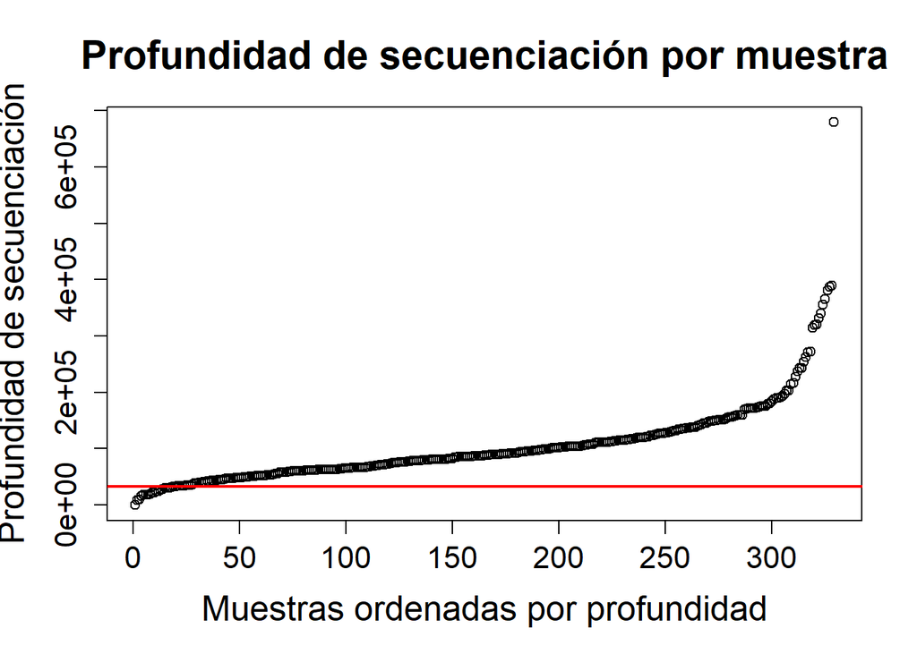

```r
plot(
  sort(sample_sums(ps_nocontrol_filtrado)),
  ylab = "Profundidad de secuenciación",
  xlab = "Muestras ordenadas por profundidad",
  main = "Profundidad de secuenciación por muestra",
  cex.lab = 1.6,
  cex.axis = 1.4,
  cex.main = 1.8
)
abline(h =  33142 , col = "red", lwd = 2)
```

## Guardado y carga

Guardado del objeto phylosec y carga de datos con la distancia filogenética.

```r
ps_nocontrol_filtrado_rare_MF <- ps_nocontrol_filtrado_rare

saveRDS(ps_nocontrol_filtrado_rare_MF, "ps_nocontrol_filtrado_rare_MF.rds")
```

En otro script, partiendo del objeto phyloseq anterior, se “mapean” sus secuencias contra una base de datos de referencia con árbol y taxonomía asociados (ej. greengenes2). De esta forma se incluye el árbol filogenético en el objeto y se pueden realizar análisis mediante medidas filogenéticas (ej.: Faith, unifrac,…)

```r
nuevosdatos <- "phyloseq_objects_with_tree.Rdata"

load(here("data",nuevosdatos ))

new_ps_MF <- new_ps
```

# **Análisis de diversidad y correlaciones**

## Creación de las variables de trabajo

```r
datos_est_MF <- as(sample_data(ps_nocontrol_filtrado_rare_MF), "data.frame")
Riqueza <- estimate_richness(ps_nocontrol_filtrado_rare_MF, measures = "Observed")
Homogeneidad <- estimate_richness(ps_nocontrol_filtrado_rare_MF, measures = "Shannon")
Faith_D <- pd(as(otu_table(new_ps_MF), "matrix"), phy_tree(new_ps_MF))
datos_est_MF$Riqueza <- Riqueza[rownames(datos_est_MF), "Observed"]
datos_est_MF$Homogeneidad <- Homogeneidad[rownames(datos_est_MF), "Shannon"]
datos_est_MF$Faith_D <- Faith_D[rownames(datos_est_MF), "PD"]

# Aseguramos los tipos de variable

datos_est_MF$Tipo_planta   <- factor(datos_est_MF$Tipo_planta)
datos_est_MF$Tipo_linea   <- factor(datos_est_MF$Tipo_linea)
datos_est_MF$Hospedador   <- factor(datos_est_MF$Hospedador)
datos_est_MF$Linea2   <- factor(datos_est_MF$Linea2)
datos_est_MF$Pase   <- factor(datos_est_MF$Pase)

#Eliminación de los controles temporales

ps_nocontrol_filtrado_rare <- subset_samples(ps_nocontrol_filtrado_rare, !(Tipo_linea %in% c("MF")))
new_ps <- subset_samples(new_ps, !(Tipo_linea %in% c("MF")))

datos_est <- as(sample_data(ps_nocontrol_filtrado_rare), "data.frame")
Riqueza <- estimate_richness(ps_nocontrol_filtrado_rare, measures = "Observed")
Homogeneidad <- estimate_richness(ps_nocontrol_filtrado_rare, measures = "Shannon")
Faith_D <- pd(as(otu_table(new_ps), "matrix"), phy_tree(new_ps))
datos_est$Riqueza <- Riqueza[rownames(datos_est), "Observed"]
datos_est$Homogeneidad <- Homogeneidad[rownames(datos_est), "Shannon"]
datos_est$Faith_D <- Faith_D[rownames(datos_est), "PD"]

# Aseguramos los tipos de variable

datos_est$Tipo_planta   <- factor(datos_est$Tipo_planta)
datos_est$Tipo_linea   <- factor(datos_est$Tipo_linea)
datos_est$Hospedador   <- factor(datos_est$Hospedador)
datos_est$Linea2   <- factor(datos_est$Linea2)
datos_est$Pase   <- factor(datos_est$Pase)
datos_est$log_MPN <- log10(datos_est$MPN)
datos_est_6 <- subset(datos_est, Pase == 6)


saveRDS(ps_nocontrol_filtrado_rare, "ps_nocontrol_filtrado_rare_noMF.rds")
```

### Representación de las variables de trabajo

Se representan los valores de las variables de trabajo según Pase, Hospedador y Transmisión.

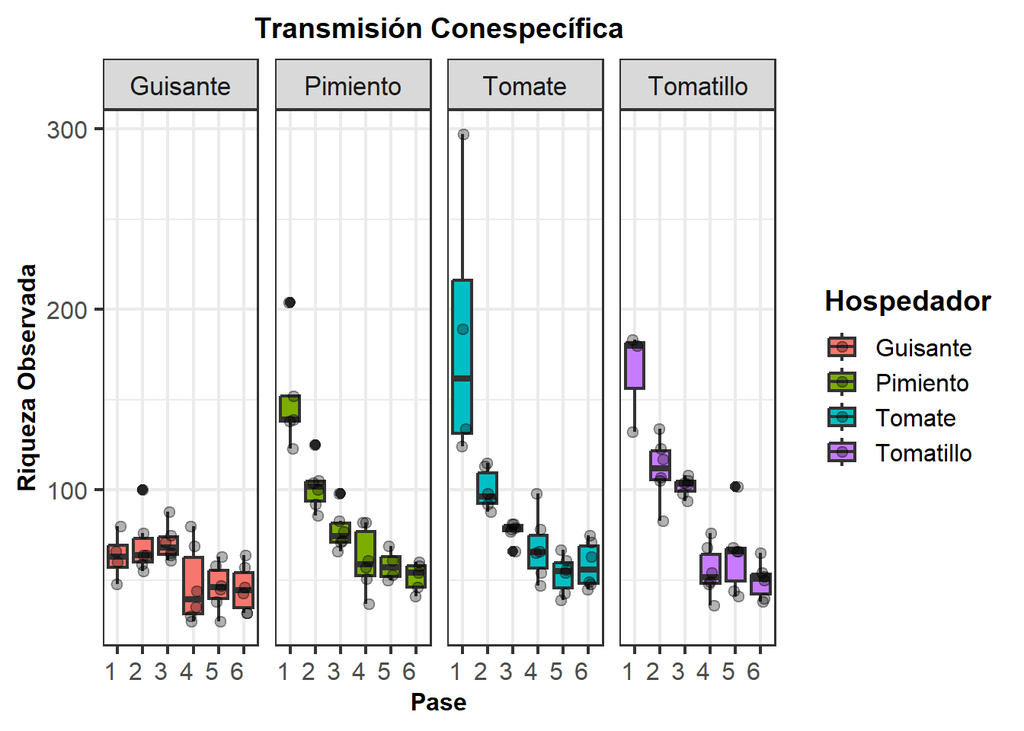

```r
Riqueza_Conespecifica <- datos_est %>%
  filter(Tipo_linea=='Conespecífica')%>%
  ggplot(aes(x=as.factor(Pase),y=Riqueza, fill=Hospedador)) +
  geom_boxplot() +
  ylab('Riqueza Observada')+
  geom_point(position=position_jitterdodge(),alpha=0.3) +
  facet_wrap(~Tipo_planta, ncol=4) +
  ggtitle('Transmisión Conespecífica')+
  theme_bw(base_size = 16)+
  # ylim(0,175)+
   labs(x = "Pase",
        fill = "Hospedador") +
 theme(
      axis.text.x = element_text(size = 12, hjust = 1),
      axis.text.y = element_text(size = 12),
      axis.title.x = element_text(size = 12, face = "bold"),
      axis.title.y = element_text(size = 12, face = "bold"),
      legend.text = element_text(size = 12),
      legend.title = element_text(size = 14, face="bold"),
      plot.title   = element_text(size = 14, face = "bold", hjust = 0.5)
    )

Riqueza_Conespecifica
```

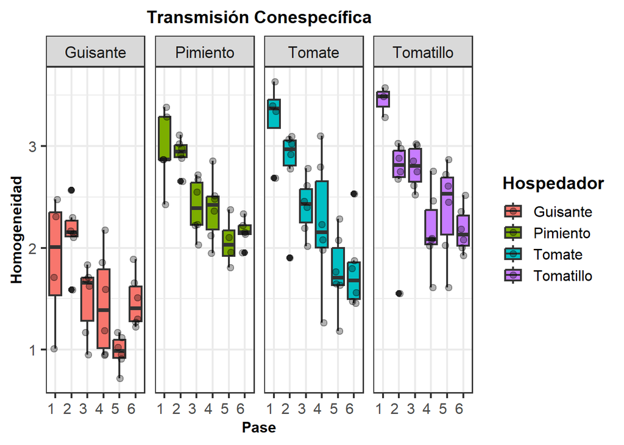

```r
Riqueza_heteroespecifica <- datos_est %>%
  filter(Tipo_linea=='Heteroespecífica') %>%
    ggplot(aes(x=as.factor(Pase),y=Riqueza, fill=Hospedador)) +
  geom_boxplot() +
  ylab('Riqueza Observada')+
  geom_point(position=position_jitterdodge(),alpha=0.3) +
  facet_wrap(~Tipo_planta, ncol=4) +
  ggtitle('Transmisión Heteroespecífica')+
  theme_bw(base_size = 16)+
  labs(x = "Pase",
       fill = "Hospedador")+
    # ylim(0,175)+
 theme(
      axis.text.x = element_text(size = 12, hjust = 1),
      axis.text.y = element_text(size = 12),
      axis.title.x = element_text(size = 12, face = "bold"),
      axis.title.y = element_text(size = 12, face = "bold"),
      legend.text = element_text(size = 12),
      legend.title = element_text(size = 14, face="bold"),
      plot.title   = element_text(size = 14, face = "bold", hjust = 0.5)
    )

panel_Riqueza <- (Riqueza_Conespecifica + Riqueza_heteroespecifica) +
            plot_layout(guides = "collect") +
            plot_annotation(tag_levels = "A", tag_suffix = ")") &
            theme(legend.position = "right")

ggsave("graficos/Riqueza.png", panel_Riqueza, width = 16, height = 6, dpi = 300)

Homogeneidad_Conespecifica <- datos_est %>%
  filter(Tipo_linea=='Conespecífica')%>%
  ggplot(aes(x=as.factor(Pase),y=Homogeneidad, fill=Hospedador)) +
  geom_boxplot() +
  ylab('Homogeneidad')+
  geom_point(position=position_jitterdodge(),alpha=0.3) +
  facet_wrap(~Tipo_planta, ncol=4) +
  ggtitle('Transmisión Conespecífica')+
  theme_bw(base_size = 16)+
  # ylim(0,175)+
   labs(x = "Pase",
        fill = "Hospedador") +
 theme(
      axis.text.x = element_text(size = 12, hjust = 1),
      axis.text.y = element_text(size = 12),
      axis.title.x = element_text(size = 12, face = "bold"),
      axis.title.y = element_text(size = 12, face = "bold"),
      legend.text = element_text(size = 12),
      legend.title = element_text(size = 14, face="bold"),
      plot.title   = element_text(size = 14, face = "bold", hjust = 0.5)
    )

Homogeneidad_Conespecifica
```

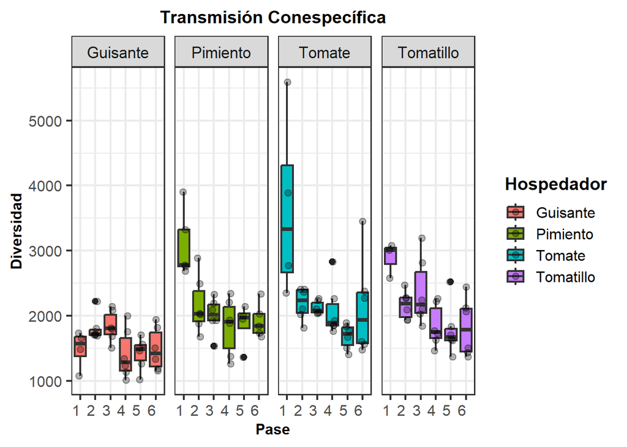

```r
Homogeneidad_heteroespecifica <- datos_est %>%
  filter(Tipo_linea=='Heteroespecífica') %>%
    ggplot(aes(x=as.factor(Pase),y=Homogeneidad, fill=Hospedador)) +
  geom_boxplot() +
  ylab('Homogeneidad')+
  geom_point(position=position_jitterdodge(),alpha=0.3) +
  facet_wrap(~Tipo_planta, ncol=4) +
  ggtitle('Transmisión Heteroespecífica')+
  theme_bw(base_size = 16)+
  labs(x = "Pase",
       fill = "Hospedador")+
    # ylim(0,175)+
 theme(
      axis.text.x = element_text(size = 12, hjust = 1),
      axis.text.y = element_text(size = 12),
      axis.title.x = element_text(size = 12, face = "bold"),
      axis.title.y = element_text(size = 12, face = "bold"),
      legend.text = element_text(size = 12),
      legend.title = element_text(size = 14, face="bold"),
      plot.title   = element_text(size = 14, face = "bold", hjust = 0.5)
    )

panel_Homogeneidad <- (Homogeneidad_Conespecifica + Homogeneidad_heteroespecifica) +
            plot_layout(guides = "collect") +
            plot_annotation(tag_levels = "A", tag_suffix = ")")  &
            theme(legend.position = "right")

ggsave("graficos/Homogeneidad.png", panel_Homogeneidad, width = 16, height = 6, dpi = 300)

Faith_Conespecifica <- datos_est %>%
  filter(Tipo_linea=='Conespecífica')%>%
  ggplot(aes(x=as.factor(Pase),y=Faith_D, fill=Hospedador)) +
  geom_boxplot() +
  ylab('Diversidad')+
  geom_point(position=position_jitterdodge(),alpha=0.3) +
  facet_wrap(~Tipo_planta, ncol=4) +
  ggtitle('Transmisión Conespecífica')+
  theme_bw(base_size = 16)+
  # ylim(0,175)+
   labs(x = "Pase",
        fill = "Hospedador") +
 theme(
      axis.text.x = element_text(size = 12, hjust = 1),
      axis.text.y = element_text(size = 12),
      axis.title.x = element_text(size = 12, face = "bold"),
      axis.title.y = element_text(size = 12, face = "bold"),
      legend.text = element_text(size = 12),
      legend.title = element_text(size = 14, face="bold"),
      plot.title   = element_text(size = 14, face = "bold", hjust = 0.5)
    )

Faith_Conespecifica
```

```r
Faith_heteroespecifica <- datos_est %>%
  filter(Tipo_linea=='Heteroespecífica') %>%
    ggplot(aes(x=as.factor(Pase),y=Faith_D, fill=Hospedador)) +
  geom_boxplot() +
  ylab('Diversidad')+
  geom_point(position=position_jitterdodge(),alpha=0.3) +
  facet_wrap(~Tipo_planta, ncol=4) +
  ggtitle('Transmisión Heteroespecífica')+
  theme_bw(base_size = 16)+
  labs(x = "Pase",
       fill = "Hospedador")+
    # ylim(0,175)+
 theme(
      axis.text.x = element_text(size = 12, hjust = 1),
      axis.text.y = element_text(size = 12),
      axis.title.x = element_text(size = 12, face = "bold"),
      axis.title.y = element_text(size = 12, face = "bold"),
      legend.text = element_text(size = 12),
      legend.title = element_text(size = 14, face="bold"),
      plot.title   = element_text(size = 14, face = "bold", hjust = 0.5)
    )


panel_Faith <- (Faith_Conespecifica + Faith_heteroespecifica) +
            plot_layout(guides = "collect") +
           plot_annotation(tag_levels = "A", tag_suffix = ")") &
            theme(legend.position = "right")

ggsave("graficos/Faith.png", panel_Faith, width = 16, height = 6, dpi = 300)

MPN_box <- datos_est_6 %>%
  ggplot(aes(x=Tipo_planta,y=log_MPN, fill=Hospedador)) +
  facet_wrap("Tipo_linea") +
  geom_boxplot() +
  ylab('log_MPN')+
  geom_point(position=position_jitterdodge(),alpha=0.3) +
  ggtitle('Carga Bacteriana')+
  theme_bw(base_size = 16)+
  # ylim(0,175)+
   labs(x = "Planta Original",
        fill = "Hospedador") +
 theme(
     axis.text.x = element_text(size = 12, angle = 45, hjust = 1),
      axis.text.y = element_text(size = 12),
      axis.title.x = element_text(size = 12, face = "bold"),
      axis.title.y = element_text(size = 12, face = "bold"),
      legend.text = element_text(size = 12),
      legend.title = element_text(size = 14, face="bold"),
      plot.title   = element_text(size = 14, face = "bold", hjust = 0.5)
    )

Peso_box <- datos_est_6 %>%
  ggplot(aes(x=Tipo_planta,y=Peso_seco, fill=Hospedador)) + facet_wrap("Tipo_linea") +
  geom_boxplot() +
  ylab('Peso seco (g)')+
  geom_point(position=position_jitterdodge(),alpha=0.3) +
  ggtitle('Peso Seco')+
  theme_bw(base_size = 16)+
  # ylim(0,175)+
   labs(x = "Planta Original",
        fill = "Hospedador") +
 theme(
     axis.text.x = element_text(size = 12, angle = 45, hjust = 1),
      axis.text.y = element_text(size = 12),
      axis.title.x = element_text(size = 12, face = "bold"),
      axis.title.y = element_text(size = 12, face = "bold"),
      legend.text = element_text(size = 12),
      legend.title = element_text(size = 14, face="bold"),
      plot.title   = element_text(size = 14, face = "bold", hjust = 0.5)
    )

panel_MPN_Peso<- (MPN_box + Peso_box) +
            plot_layout(guides = "collect") +
           plot_annotation(tag_levels = "A", tag_suffix = ")") &
            theme(legend.position = "right")

ggsave("graficos/MPN_Peso.png", panel_MPN_Peso, width = 16, height = 6, dpi = 300)
```

### Análisis estadístico

Se analiza estadísticamente el efecto de Pase, Hospedador, Transmisión y de la interacción entre Hospedador y Transmisión sobre Riqueza, Homogeneidad y diversidad filogenética.  
En el último pase de muestreo se analiza el efecto de Transmisión sobre Riqueza, Homogeneidad y diversidad filogenética.  
También en el último pase de muestreo se analizan los efectos de la especie de planta sobre las variables Carga y Peso.

```r
datos_est$Tipo_linea <- relevel(factor(datos_est$Tipo_linea),ref = "Conespecífica")
contrasts(datos_est$Tipo_linea)
```

```
##                  Heteroespecífica
## Conespecífica                   0
## Heteroespecífica                1
```

```r
datos_est$Hospedador <- factor(datos_est$Hospedador,levels = c("Tomate", "Guisante", "Pimiento", "Tomatillo"))
contrasts(datos_est$Hospedador)
```

```
##           Guisante Pimiento Tomatillo
## Tomate           0        0         0
## Guisante         1        0         0
## Pimiento         0        1         0
## Tomatillo        0        0         1
```

```r
datos_est_6$Tipo_linea <- relevel(factor(datos_est_6$Tipo_linea),ref = "Conespecífica")
contrasts(datos_est_6$Tipo_linea)
```

```
##                  Heteroespecífica
## Conespecífica                   0
## Heteroespecífica                1
```

```r
datos_est_6$Hospedador <- factor(datos_est_6$Hospedador,levels = c("Tomate", "Guisante", "Pimiento", "Tomatillo"))
contrasts(datos_est_6$Hospedador)
```

```
##           Guisante Pimiento Tomatillo
## Tomate           0        0         0
## Guisante         1        0         0
## Pimiento         0        1         0
## Tomatillo        0        0         1
```

```r
datos_est_6$Tipo_planta <- factor(datos_est_6$Tipo_planta,levels = c("Tomate", "Guisante", "Pimiento", "Tomatillo"))
contrasts(datos_est_6$Tipo_planta)
```

```
##           Guisante Pimiento Tomatillo
## Tomate           0        0         0
## Guisante         1        0         0
## Pimiento         0        1         0
## Tomatillo        0        0         1
```

```r
# ========================================================================
# Análisis Riqueza
# ========================================================================

modelo_lmer_Riqueza <- lmer(Riqueza ~ Pase + Hospedador * Tipo_linea + (1 | LineaId), data = datos_est, REML = FALSE)
summary(modelo_lmer_Riqueza)
```

```
## Linear mixed model fit by maximum likelihood . t-tests use Satterthwaite's
##   method [lmerModLmerTest]
## Formula: Riqueza ~ Pase + Hospedador * Tipo_linea + (1 | LineaId)
##    Data: datos_est
##
##       AIC       BIC    logLik -2*log(L)  df.resid
##    2138.6    2190.3   -1054.3    2108.6       217
##
## Scaled residuals:
##     Min      1Q  Median      3Q     Max
## -3.2157 -0.4983 -0.1385  0.5284  6.3736
##
## Random effects:
##  Groups   Name        Variance Std.Dev.
##  LineaId  (Intercept)  30.25    5.50
##  Residual             492.22   22.19
## Number of obs: 232, groups:  LineaId, 42
##
## Fixed effects:
##                                                Estimate Std. Error      df
## (Intercept)                                     149.291      6.079 101.270
## Pase2                                           -42.037      5.967 198.243
## Pase3                                           -62.325      5.389 202.261
## Pase4                                           -86.107      5.996 206.542
## Pase5                                           -83.938      5.505 212.069
## Pase6                                           -91.716      6.036 206.530
## HospedadorGuisante                              -27.679      6.264  34.519
## HospedadorPimiento                               -4.508      6.345  36.111
## HospedadorTomatillo                               2.495      6.501  27.194
## Tipo_lineaHeteroespecífica                        3.081      5.867  55.567
## HospedadorGuisante:Tipo_lineaHeteroespecífica    -4.614      9.884 119.309
## HospedadorPimiento:Tipo_lineaHeteroespecífica    11.468      9.841 118.860
## HospedadorTomatillo:Tipo_lineaHeteroespecífica   -1.066     10.268 106.937
##                                                t value Pr(>|t|)
## (Intercept)                                     24.559  < 2e-16 ***
## Pase2                                           -7.045 2.99e-11 ***
## Pase3                                          -11.565  < 2e-16 ***
## Pase4                                          -14.361  < 2e-16 ***
## Pase5                                          -15.248  < 2e-16 ***
## Pase6                                          -15.195  < 2e-16 ***
## HospedadorGuisante                              -4.419 9.37e-05 ***
## HospedadorPimiento                              -0.711    0.482
## HospedadorTomatillo                              0.384    0.704
## Tipo_lineaHeteroespecífica                       0.525    0.602
## HospedadorGuisante:Tipo_lineaHeteroespecífica   -0.467    0.641
## HospedadorPimiento:Tipo_lineaHeteroespecífica    1.165    0.246
## HospedadorTomatillo:Tipo_lineaHeteroespecífica  -0.104    0.917
## ---
## Signif. codes:  0 '***' 0.001 '**' 0.01 '*' 0.05 '.' 0.1 ' ' 1
```

```
##
## Correlation matrix not shown by default, as p = 13 > 12.
## Use print(x, correlation=TRUE)  or
##     vcov(x)        if you need it
```

```r
anova(modelo_lmer_Riqueza)
```

```
## Type III Analysis of Variance Table with Satterthwaite's method
##                       Sum Sq Mean Sq NumDF   DenDF F value    Pr(>F)
## Pase                  190724   38145     5 198.357 77.4951 < 2.2e-16 ***
## Hospedador             26096    8699     3  94.222 17.6719 3.509e-09 ***
## Tipo_linea               684     684     1  48.742  1.3889    0.2443
## Hospedador:Tipo_linea   1315     438     3  94.027  0.8907    0.4490
## ---
## Signif. codes:  0 '***' 0.001 '**' 0.01 '*' 0.05 '.' 0.1 ' ' 1
```

```r
modelo_lmer_Riqueza_pase6 <- lmer(Riqueza ~ Tipo_linea + (1 | LineaId), data = datos_est_6, REML = FALSE)
summary(modelo_lmer_Riqueza_pase6)
```

```
## Linear mixed model fit by maximum likelihood . t-tests use Satterthwaite's
##   method [lmerModLmerTest]
## Formula: Riqueza ~ Tipo_linea + (1 | LineaId)
##    Data: datos_est_6
##
##       AIC       BIC    logLik -2*log(L)  df.resid
##     359.6     366.4    -175.8     351.6        36
##
## Scaled residuals:
##      Min       1Q   Median       3Q      Max
## -1.10178 -0.30824 -0.07835  0.30625  2.34034
##
## Random effects:
##  Groups   Name        Variance Std.Dev.
##  LineaId  (Intercept) 361      19.0
##  Residual             104      10.2
## Number of obs: 40, groups:  LineaId, 32
##
## Fixed effects:
##                            Estimate Std. Error     df t value Pr(>|t|)
## (Intercept)                  51.842      4.893 30.413  10.596 9.93e-12 ***
## Tipo_lineaHeteroespecífica    8.461      7.640 29.697   1.107    0.277
## ---
## Signif. codes:  0 '***' 0.001 '**' 0.01 '*' 0.05 '.' 0.1 ' ' 1
```

```
##
## Correlation of Fixed Effects:
```

```
##             (Intr)
## Tp_lnHtrspc -0.640
```

```r
anova(modelo_lmer_Riqueza_pase6)
```

```
## Type III Analysis of Variance Table with Satterthwaite's method
##            Sum Sq Mean Sq NumDF  DenDF F value Pr(>F)
## Tipo_linea 127.61  127.61     1 29.697  1.2264  0.277
```

```r
modelo_lm_Riqueza_pase6 <- lm(Riqueza ~ Tipo_linea, data = datos_est_6)
summary(modelo_lm_Riqueza_pase6)
```

```
##
## Call:
## lm(formula = Riqueza ~ Tipo_linea, data = datos_est_6)
##
## Residuals:
##     Min      1Q  Median      3Q     Max
## -21.235 -10.285  -2.935   3.465 108.765
##
## Coefficients:
##                            Estimate Std. Error t value Pr(>|t|)
## (Intercept)                  51.435      4.338  11.856 2.46e-14 ***
## Tipo_lineaHeteroespecífica    6.801      6.655   1.022    0.313
## ---
## Signif. codes:  0 '***' 0.001 '**' 0.01 '*' 0.05 '.' 0.1 ' ' 1
##
## Residual standard error: 20.81 on 38 degrees of freedom
## Multiple R-squared:  0.02674,    Adjusted R-squared:  0.001133
## F-statistic: 1.044 on 1 and 38 DF,  p-value: 0.3133
```

```r
anova(modelo_lm_Riqueza_pase6)
```

```
## Analysis of Variance Table
##
## Response: Riqueza
##            Df  Sum Sq Mean Sq F value Pr(>F)
## Tipo_linea  1   452.1  452.06  1.0442 0.3133
## Residuals  38 16450.7  432.91
```

```r
lmtest::bptest(modelo_lm_Riqueza_pase6)
```

```
##
##  studentized Breusch-Pagan test
##
## data:  modelo_lm_Riqueza_pase6
## BP = 1.2921, df = 1, p-value = 0.2557
```

```r
# ========================================================================
# Análisis Homogeneidad
# ========================================================================

modelo_lmer_Homogeneidad <- lmer(Homogeneidad ~ Pase + Hospedador * Tipo_linea + (1 | LineaId), data = datos_est, REML = FALSE)
summary(modelo_lmer_Homogeneidad)
```

```
## Linear mixed model fit by maximum likelihood . t-tests use Satterthwaite's
##   method [lmerModLmerTest]
## Formula: Homogeneidad ~ Pase + Hospedador * Tipo_linea + (1 | LineaId)
##    Data: datos_est
##
##       AIC       BIC    logLik -2*log(L)  df.resid
##     243.9     295.6    -106.9     213.9       217
##
## Scaled residuals:
##     Min      1Q  Median      3Q     Max
## -3.2900 -0.5592  0.0618  0.7095  2.1059
##
## Random effects:
##  Groups   Name        Variance Std.Dev.
##  LineaId  (Intercept) 0.02922  0.1709
##  Residual             0.12758  0.3572
## Number of obs: 232, groups:  LineaId, 42
##
## Fixed effects:
##                                                 Estimate Std. Error        df
## (Intercept)                                      3.01477    0.11541  61.27377
## Pase2                                           -0.25088    0.09670 185.98876
## Pase3                                           -0.70445    0.08754 189.62995
## Pase4                                           -0.90287    0.09764 193.46228
## Pase5                                           -1.06728    0.08996 198.69380
## Pase6                                           -0.98762    0.09830 193.79596
## HospedadorGuisante                              -0.76764    0.13175  26.66010
## HospedadorPimiento                               0.12964    0.13281  27.50442
## HospedadorTomatillo                              0.19248    0.13871  26.30942
## Tipo_lineaHeteroespecífica                      -0.02034    0.11761  37.56224
## HospedadorGuisante:Tipo_lineaHeteroespecífica    0.19126    0.18400  80.22123
## HospedadorPimiento:Tipo_lineaHeteroespecífica    0.23174    0.18308  81.18593
## HospedadorTomatillo:Tipo_lineaHeteroespecífica   0.07855    0.19208  79.86427
##                                                t value Pr(>|t|)
## (Intercept)                                     26.122  < 2e-16 ***
## Pase2                                           -2.595   0.0102 *
## Pase3                                           -8.047 9.04e-14 ***
## Pase4                                           -9.247  < 2e-16 ***
## Pase5                                          -11.864  < 2e-16 ***
## Pase6                                          -10.047  < 2e-16 ***
## HospedadorGuisante                              -5.826 3.51e-06 ***
## HospedadorPimiento                               0.976   0.3375
## HospedadorTomatillo                              1.388   0.1769
## Tipo_lineaHeteroespecífica                      -0.173   0.8637
## HospedadorGuisante:Tipo_lineaHeteroespecífica    1.039   0.3017
## HospedadorPimiento:Tipo_lineaHeteroespecífica    1.266   0.2092
## HospedadorTomatillo:Tipo_lineaHeteroespecífica   0.409   0.6837
## ---
## Signif. codes:  0 '***' 0.001 '**' 0.01 '*' 0.05 '.' 0.1 ' ' 1
```

```
##
## Correlation matrix not shown by default, as p = 13 > 12.
## Use print(x, correlation=TRUE)  or
##     vcov(x)        if you need it
```

```r
anova(modelo_lmer_Homogeneidad)
```

```
## Type III Analysis of Variance Table with Satterthwaite's method
##                        Sum Sq Mean Sq NumDF   DenDF F value    Pr(>F)
## Pase                  30.6317  6.1263     5 185.215 48.0199 < 2.2e-16 ***
## Hospedador            14.1566  4.7189     3  77.792 36.9876  5.84e-15 ***
## Tipo_linea             0.2327  0.2327     1  35.500  1.8243    0.1853
## Hospedador:Tipo_linea  0.2537  0.0846     3  77.677  0.6628    0.5774
## ---
## Signif. codes:  0 '***' 0.001 '**' 0.01 '*' 0.05 '.' 0.1 ' ' 1
```

```r
modelo_lmer_Homogeneidad_pase6 <- lmer(Homogeneidad ~ Tipo_linea + (1 | LineaId), data = datos_est_6, REML = FALSE)
summary(modelo_lmer_Homogeneidad_pase6)
```

```
## Linear mixed model fit by maximum likelihood . t-tests use Satterthwaite's
##   method [lmerModLmerTest]
## Formula: Homogeneidad ~ Tipo_linea + (1 | LineaId)
##    Data: datos_est_6
##
##       AIC       BIC    logLik -2*log(L)  df.resid
##      34.4      41.2     -13.2      26.4        36
##
## Scaled residuals:
##      Min       1Q   Median       3Q      Max
## -1.02608 -0.60615  0.02226  0.44182  1.47340
##
## Random effects:
##  Groups   Name        Variance Std.Dev.
##  LineaId  (Intercept) 0.08666  0.2944
##  Residual             0.04182  0.2045
## Number of obs: 40, groups:  LineaId, 32
##
## Fixed effects:
##                            Estimate Std. Error       df t value Pr(>|t|)
## (Intercept)                 1.86757    0.08083 31.32138  23.105   <2e-16 ***
## Tipo_lineaHeteroespecífica  0.18547    0.12593 30.31462   1.473    0.151
## ---
## Signif. codes:  0 '***' 0.001 '**' 0.01 '*' 0.05 '.' 0.1 ' ' 1
```

```
##
## Correlation of Fixed Effects:
```

```
##             (Intr)
## Tp_lnHtrspc -0.642
```

```r
anova(modelo_lmer_Homogeneidad_pase6)
```

```
## Type III Analysis of Variance Table with Satterthwaite's method
##              Sum Sq  Mean Sq NumDF  DenDF F value Pr(>F)
## Tipo_linea 0.090721 0.090721     1 30.315  2.1691 0.1511
```

```r
modelo_lm_Homogeneidad_pase6 <- lm(Homogeneidad ~ Tipo_linea, data = datos_est_6)
summary(modelo_lm_Homogeneidad_pase6)
```

```
##
## Call:
## lm(formula = Homogeneidad ~ Tipo_linea, data = datos_est_6)
##
## Residuals:
##      Min       1Q   Median       3Q      Max
## -0.66414 -0.28702  0.05062  0.25067  0.64442
##
## Coefficients:
##                            Estimate Std. Error t value Pr(>|t|)
## (Intercept)                 1.88705    0.07519  25.098   <2e-16 ***
## Tipo_lineaHeteroespecífica  0.16887    0.11533   1.464    0.151
## ---
## Signif. codes:  0 '***' 0.001 '**' 0.01 '*' 0.05 '.' 0.1 ' ' 1
##
## Residual standard error: 0.3606 on 38 degrees of freedom
## Multiple R-squared:  0.0534, Adjusted R-squared:  0.02849
## F-statistic: 2.144 on 1 and 38 DF,  p-value: 0.1514
```

```r
anova(modelo_lm_Homogeneidad_pase6)
```

```
## Analysis of Variance Table
##
## Response: Homogeneidad
##            Df Sum Sq Mean Sq F value Pr(>F)
## Tipo_linea  1 0.2788 0.27875  2.1438 0.1514
## Residuals  38 4.9409 0.13002
```

```r
lmtest::bptest(modelo_lm_Homogeneidad_pase6)
```

```
##
##  studentized Breusch-Pagan test
##
## data:  modelo_lm_Homogeneidad_pase6
## BP = 2.2141, df = 1, p-value = 0.1368
```

```r
# ========================================================================
# Análisis diversidad filogenética
# ========================================================================

modelo_lmer_Faith_D <- lmer(Faith_D ~ Pase + Hospedador * Tipo_linea + (1 | LineaId), data = datos_est, REML = FALSE)
summary(modelo_lmer_Faith_D)
```

```
## Linear mixed model fit by maximum likelihood . t-tests use Satterthwaite's
##   method [lmerModLmerTest]
## Formula: Faith_D ~ Pase + Hospedador * Tipo_linea + (1 | LineaId)
##    Data: datos_est
##
##       AIC       BIC    logLik -2*log(L)  df.resid
##    3523.3    3575.0   -1746.6    3493.3       217
##
## Scaled residuals:
##     Min      1Q  Median      3Q     Max
## -2.7799 -0.5487 -0.0671  0.4321  6.7640
##
## Random effects:
##  Groups   Name        Variance Std.Dev.
##  LineaId  (Intercept)  21102   145.3
##  Residual             186029   431.3
## Number of obs: 232, groups:  LineaId, 42
##
## Fixed effects:
##                                                Estimate Std. Error       df
## (Intercept)                                     3003.43     125.24    93.43
## Pase2                                           -658.45     116.30   198.83
## Pase3                                           -753.21     105.14   202.35
## Pase4                                          -1042.74     117.10   206.04
## Pase5                                          -1024.22     107.67   210.91
## Pase6                                           -935.57     117.88   206.18
## HospedadorGuisante                              -637.91     134.51    36.00
## HospedadorPimiento                              -131.12     135.98    37.42
## HospedadorTomatillo                             -141.41     140.86    31.69
## Tipo_lineaHeteroespecífica                        59.55     123.51    54.42
## HospedadorGuisante:Tipo_lineaHeteroespecífica   -108.57     202.35   113.59
## HospedadorPimiento:Tipo_lineaHeteroespecífica    301.49     201.45   114.25
## HospedadorTomatillo:Tipo_lineaHeteroespecífica   172.89     210.83   106.71
##                                                t value Pr(>|t|)
## (Intercept)                                     23.981  < 2e-16 ***
## Pase2                                           -5.662 5.19e-08 ***
## Pase3                                           -7.164 1.43e-11 ***
## Pase4                                           -8.904 2.82e-16 ***
## Pase5                                           -9.513  < 2e-16 ***
## Pase6                                           -7.936 1.31e-13 ***
## HospedadorGuisante                              -4.742 3.29e-05 ***
## HospedadorPimiento                              -0.964    0.341
## HospedadorTomatillo                             -1.004    0.323
## Tipo_lineaHeteroespecífica                       0.482    0.632
## HospedadorGuisante:Tipo_lineaHeteroespecífica   -0.537    0.593
## HospedadorPimiento:Tipo_lineaHeteroespecífica    1.497    0.137
## HospedadorTomatillo:Tipo_lineaHeteroespecífica   0.820    0.414
## ---
## Signif. codes:  0 '***' 0.001 '**' 0.01 '*' 0.05 '.' 0.1 ' ' 1
```

```
##
## Correlation matrix not shown by default, as p = 13 > 12.
## Use print(x, correlation=TRUE)  or
##     vcov(x)        if you need it
```

```r
anova(modelo_lmer_Faith_D)
```

```
## Type III Analysis of Variance Table with Satterthwaite's method
##                         Sum Sq Mean Sq NumDF   DenDF F value    Pr(>F)
## Pase                  22163500 4432700     5 198.724 23.8280 < 2.2e-16 ***
## Hospedador            11385837 3795279     3  99.182 20.4016 2.237e-10 ***
## Tipo_linea              642581  642581     1  49.478  3.4542   0.06904 .
## Hospedador:Tipo_linea   805273  268424     3  99.067  1.4429   0.23491
## ---
## Signif. codes:  0 '***' 0.001 '**' 0.01 '*' 0.05 '.' 0.1 ' ' 1
```

```r
modelo_lmer_Faith_D_pase6 <- lmer(Faith_D ~ Tipo_linea + (1 | LineaId), data = datos_est_6, REML = FALSE)
summary(modelo_lmer_Faith_D_pase6)
```

```
## Linear mixed model fit by maximum likelihood . t-tests use Satterthwaite's
##   method [lmerModLmerTest]
## Formula: Faith_D ~ Tipo_linea + (1 | LineaId)
##    Data: datos_est_6
##
##       AIC       BIC    logLik -2*log(L)  df.resid
##     640.9     647.6    -316.4     632.9        36
##
## Scaled residuals:
##     Min      1Q  Median      3Q     Max
## -1.2727 -0.3863 -0.1092  0.2481  2.6688
##
## Random effects:
##  Groups   Name        Variance Std.Dev.
##  LineaId  (Intercept) 317851   563.8
##  Residual             170148   412.5
## Number of obs: 40, groups:  LineaId, 32
##
## Fixed effects:
##                            Estimate Std. Error      df t value Pr(>|t|)
## (Intercept)                 1834.47     157.29   28.06  11.663 2.82e-12 ***
## Tipo_lineaHeteroespecífica   349.62     244.93   26.74   1.427    0.165
## ---
## Signif. codes:  0 '***' 0.001 '**' 0.01 '*' 0.05 '.' 0.1 ' ' 1
```

```
##
## Correlation of Fixed Effects:
```

```
##             (Intr)
## Tp_lnHtrspc -0.642
```

```r
anova(modelo_lmer_Faith_D_pase6)
```

```
## Type III Analysis of Variance Table with Satterthwaite's method
##            Sum Sq Mean Sq NumDF  DenDF F value Pr(>F)
## Tipo_linea 346697  346697     1 26.744  2.0376  0.165
```

```r
modelo_lm_Faith_D_pase6 <- lm(Faith_D ~ Tipo_linea, data = datos_est_6)
summary(modelo_lm_Faith_D_pase6)
```

```
##
## Call:
## lm(formula = Faith_D ~ Tipo_linea, data = datos_est_6)
##
## Residuals:
##    Min     1Q Median     3Q    Max
## -684.5 -360.1 -141.2  202.6 3192.9
##
## Coefficients:
##                            Estimate Std. Error t value Pr(>|t|)
## (Intercept)                  1837.0      142.5  12.895 1.88e-15 ***
## Tipo_lineaHeteroespecífica    311.5      218.5   1.426    0.162
## ---
## Signif. codes:  0 '***' 0.001 '**' 0.01 '*' 0.05 '.' 0.1 ' ' 1
##
## Residual standard error: 683.2 on 38 degrees of freedom
## Multiple R-squared:  0.05077,    Adjusted R-squared:  0.02579
## F-statistic: 2.032 on 1 and 38 DF,  p-value: 0.1621
```

```r
anova(modelo_lm_Faith_D_pase6)
```

```
## Analysis of Variance Table
##
## Response: Faith_D
##            Df   Sum Sq Mean Sq F value Pr(>F)
## Tipo_linea  1   948741  948741  2.0325 0.1621
## Residuals  38 17737863  466786
```

```r
lmtest::bptest(modelo_lm_Faith_D_pase6)
```

```
##
##  studentized Breusch-Pagan test
##
## data:  modelo_lm_Faith_D_pase6
## BP = 0.71587, df = 1, p-value = 0.3975
```

```r
# ========================================================================
# Análisis Carga y Peso
# ========================================================================

Conespe_6 <- subset(datos_est_6, Tipo_linea == "Conespecífica")
Heteroespe_6 <- subset(datos_est_6,Tipo_linea == "Heteroespecífica" | Tipo_planta == "Tomate")

modelo_lm_MPN_cones <- lm(log_MPN ~  Hospedador, data = Conespe_6)
summary(modelo_lm_MPN_cones)
```

```
##
## Call:
## lm(formula = log_MPN ~ Hospedador, data = Conespe_6)
##
## Residuals:
##      Min       1Q   Median       3Q      Max
## -1.05916 -0.55656 -0.05916  0.50113  1.39081
##
## Coefficients:
##                     Estimate Std. Error t value Pr(>|t|)
## (Intercept)           8.2046     0.2893  28.357   <2e-16 ***
## HospedadorGuisante   -0.5020     0.4092  -1.227    0.235
## HospedadorPimiento   -0.4900     0.4291  -1.142    0.268
## HospedadorTomatillo  -0.2181     0.4092  -0.533    0.600
## ---
## Signif. codes:  0 '***' 0.001 '**' 0.01 '*' 0.05 '.' 0.1 ' ' 1
##
## Residual standard error: 0.7087 on 19 degrees of freedom
## Multiple R-squared:  0.09527,    Adjusted R-squared:  -0.04759
## F-statistic: 0.6669 on 3 and 19 DF,  p-value: 0.5827
```

```r
Anova(modelo_lm_MPN_cones, type = 2)
```

```
## Anova Table (Type II tests)
##
## Response: log_MPN
##            Sum Sq Df F value Pr(>F)
## Hospedador 1.0049  3  0.6669 0.5827
## Residuals  9.5433 19
```

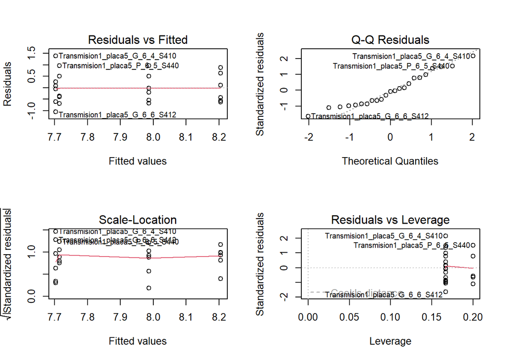

```r
par(mfrow = c(2,2)); plot(modelo_lm_MPN_cones); par(mfrow = c(1,1))
```

```r
lmtest::bptest(modelo_lm_MPN_cones)
```

```
##
##  studentized Breusch-Pagan test
##
## data:  modelo_lm_MPN_cones
## BP = 1.198, df = 3, p-value = 0.7535
```

```r
modelo_lm_MPN_Heteros <- lm(log_MPN ~  Tipo_planta, data = Heteroespe_6)
summary(modelo_lm_MPN_Heteros)
```

```
##
## Call:
## lm(formula = log_MPN ~ Tipo_planta, data = Heteroespe_6)
##
## Residuals:
##      Min       1Q   Median       3Q      Max
## -0.74021 -0.40929 -0.01057  0.27600  0.88880
##
## Coefficients:
##                      Estimate Std. Error t value Pr(>|t|)
## (Intercept)            8.2046     0.2155  38.078   <2e-16 ***
## Tipo_plantaGuisante   -0.7044     0.3196  -2.204    0.040 *
## Tipo_plantaPimiento   -0.1690     0.3047  -0.555    0.586
## Tipo_plantaTomatillo  -0.2496     0.3047  -0.819    0.423
## ---
## Signif. codes:  0 '***' 0.001 '**' 0.01 '*' 0.05 '.' 0.1 ' ' 1
##
## Residual standard error: 0.5278 on 19 degrees of freedom
## Multiple R-squared:  0.2143, Adjusted R-squared:  0.0902
## F-statistic: 1.727 on 3 and 19 DF,  p-value: 0.1954
```

```r
Anova(modelo_lm_MPN_Heteros, type = 2)
```

```
## Anova Table (Type II tests)
##
## Response: log_MPN
##             Sum Sq Df F value Pr(>F)
## Tipo_planta 1.4432  3   1.727 0.1954
## Residuals   5.2925 19
```

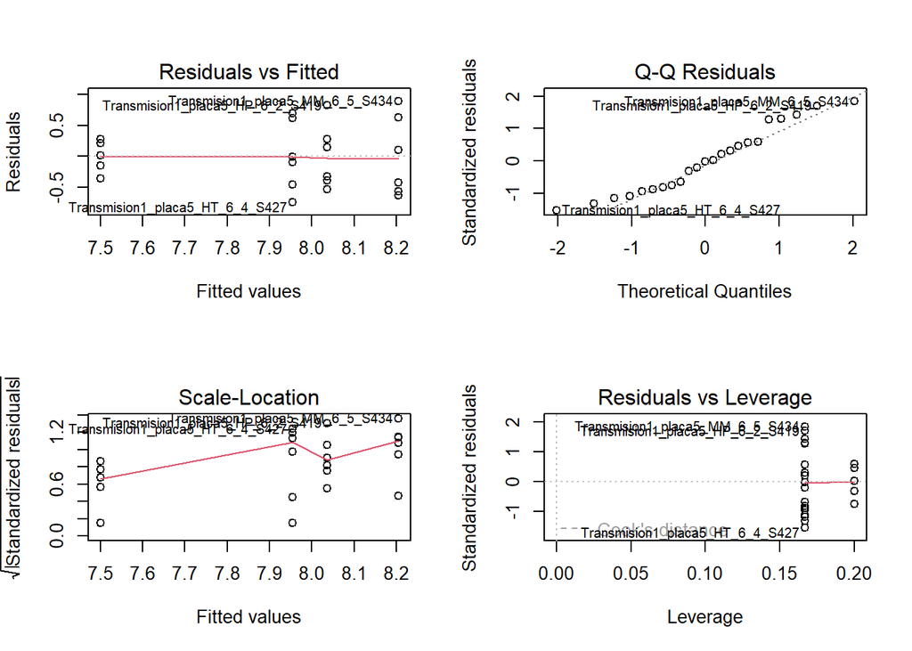

```r
par(mfrow = c(2,2)); plot(modelo_lm_MPN_Heteros); par(mfrow = c(1,1))
```

```r
lmtest::bptest(modelo_lm_MPN_Heteros)
```

```
##
##  studentized Breusch-Pagan test
##
## data:  modelo_lm_MPN_Heteros
## BP = 4.9183, df = 3, p-value = 0.1779
```

```r
modelo_lm_Peso_cones <- lm(Peso_seco ~  Hospedador, data = Conespe_6)
summary(modelo_lm_Peso_cones)
```

```
##
## Call:
## lm(formula = Peso_seco ~ Hospedador, data = Conespe_6)
##
## Residuals:
##       Min        1Q    Median        3Q       Max
## -0.079080 -0.011617  0.000083  0.007092  0.200320
##
## Coefficients:
##                      Estimate Std. Error t value Pr(>|t|)
## (Intercept)          0.027250   0.022920   1.189   0.2491
## HospedadorGuisante   0.030867   0.032414   0.952   0.3529
## HospedadorPimiento   0.060430   0.033996   1.778   0.0915 .
## HospedadorTomatillo -0.008083   0.032414  -0.249   0.8057
## ---
## Signif. codes:  0 '***' 0.001 '**' 0.01 '*' 0.05 '.' 0.1 ' ' 1
##
## Residual standard error: 0.05614 on 19 degrees of freedom
## Multiple R-squared:  0.2108, Adjusted R-squared:  0.08616
## F-statistic: 1.691 on 3 and 19 DF,  p-value: 0.2026
```

```r
Anova(modelo_lm_Peso_cones, type = 2)
```

```
## Anova Table (Type II tests)
##
## Response: Peso_seco
##              Sum Sq Df F value Pr(>F)
## Hospedador 0.015994  3  1.6914 0.2026
## Residuals  0.059889 19
```

```r
lmtest::bptest(modelo_lm_Peso_cones)
```

```
##
##  studentized Breusch-Pagan test
##
## data:  modelo_lm_Peso_cones
## BP = 7.426, df = 3, p-value = 0.05949
```

```r
modelo_lm_Peso_Heteros <- lm(Peso_seco ~  Tipo_planta, data = Heteroespe_6)
summary(modelo_lm_Peso_Heteros)
```

```
##
## Call:
## lm(formula = Peso_seco ~ Tipo_planta, data = Heteroespe_6)
##
## Residuals:
##       Min        1Q    Median        3Q       Max
## -0.017417 -0.006925 -0.002760  0.009017  0.020050
##
## Coefficients:
##                       Estimate Std. Error t value Pr(>|t|)
## (Intercept)           0.027250   0.004662   5.845 1.25e-05 ***
## Tipo_plantaGuisante  -0.004890   0.006915  -0.707    0.488
## Tipo_plantaPimiento  -0.004417   0.006593  -0.670    0.511
## Tipo_plantaTomatillo  0.006267   0.006593   0.950    0.354
## ---
## Signif. codes:  0 '***' 0.001 '**' 0.01 '*' 0.05 '.' 0.1 ' ' 1
##
## Residual standard error: 0.01142 on 19 degrees of freedom
## Multiple R-squared:  0.1579, Adjusted R-squared:  0.02489
## F-statistic: 1.187 on 3 and 19 DF,  p-value: 0.3411
```

```r
Anova(modelo_lm_Peso_Heteros, type = 2)
```

```
## Anova Table (Type II tests)
##
## Response: Peso_seco
##                 Sum Sq Df F value Pr(>F)
## Tipo_planta 0.00046448  3  1.1872 0.3411
## Residuals   0.00247795 19
```

```r
lmtest::bptest(modelo_lm_Peso_Heteros)
```

```
##
##  studentized Breusch-Pagan test
##
## data:  modelo_lm_Peso_Heteros
## BP = 2.0616, df = 3, p-value = 0.5597
```

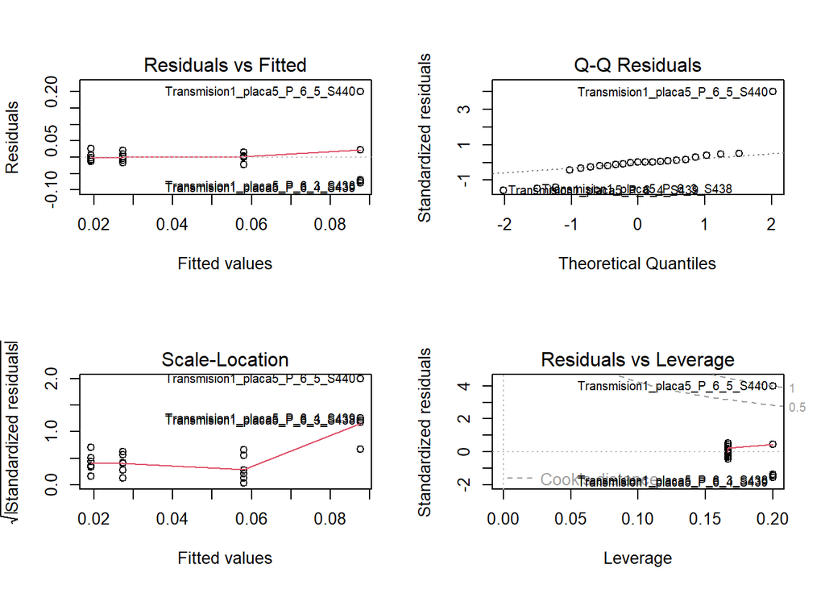

```r
par(mfrow = c(2,2)); plot(modelo_lm_Peso_cones); par(mfrow = c(1,1))
```

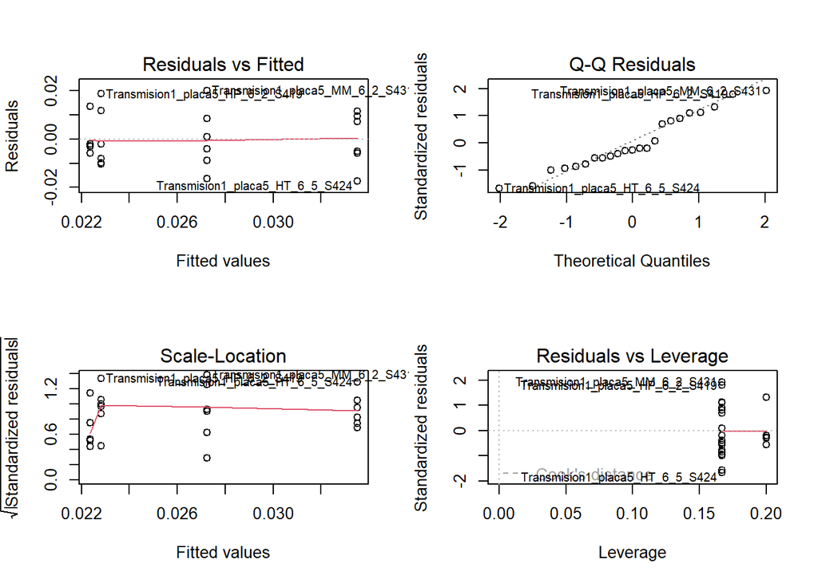

```r
par(mfrow = c(2,2)); plot(modelo_lm_Peso_Heteros); par(mfrow = c(1,1))
```

### Efecto de Riqueza y la diversidad filogenética sobre Carga y Peso

Se calcula el efecto de Riqueza y la diversidad filogenética sobre Carga y Peso. Primero se analiza si existe una correlación entre ambas variables y, en caso de detectarse, se calcula la fracción de la diversidad filogenética que es independiente de Riqueza. A continuación, se calculan los efectos de Riqueza y la fracción de la diversidad filogenética independiente de Riqueza sobre Carga y Peso.

```r
# 1) Exploración inicial ---------------------------------------------------
# Scatterplot de Riqueza vs Faith_D con smoothing y recta para ver linealidad
png("graficos/riqueza_vs_faith.png", width = 800, height = 600)

par(mar = c(5, 6.5, 4, 2) + 0.1,
    mgp = c(2.5, 0.8, 0))

plot(datos_est$Riqueza, datos_est$Faith_D,
     xlab = "Riqueza", ylab = "Diversidad",
     main = "Riqueza frente a Diversidad",
     cex.lab = 1.8,
     cex.axis = 1.6,
     cex.main = 2.2,
     cex = 1.2,
     pch = 20, col = "grey30")

lines(lowess(datos_est$Riqueza, datos_est$Faith_D), col = "blue")
abline(lm(Faith_D ~ Riqueza, data = datos_est), col = "red", lwd = 2)

dev.off()
```

```r
# Correlación
res_cor <- cor.test(datos_est$Riqueza, datos_est$Faith_D, method = "pearson")
print(res_cor)
```

```
##
##  Pearson's product-moment correlation
##
## data:  datos_est$Riqueza and datos_est$Faith_D
## t = 25.647, df = 230, p-value < 2.2e-16
## alternative hypothesis: true correlation is not equal to 0
## 95 percent confidence interval:
##  0.8232386 0.8908069
## sample estimates:
##       cor
## 0.8607683
```

```r
res_cor$estimate
```

```
##       cor
## 0.8607683
```

```r
res_cor$p.value
```

```
## [1] 2.13587e-69
```

```r
# 2) Residualizar Faith_D respecto a Riqueza (fracción de la diversidad de Faith independiente de Riqueza ) ----

m_pd_vs_r <- lm(Faith_D ~ Riqueza, data = datos_est_6)
datos_est_6$PD_resid <- resid(m_pd_vs_r)   # PD residualizado (parte no explicada por Riqueza)

# Modelo final con la PD residualizada

modelo_lmer_peso_resid <- lmer(Peso_seco ~ Riqueza + PD_resid + (1 | LineaId), data = datos_est_6)
## boundary (singular) fit: see help('isSingular')
print(summary(modelo_lmer_peso_resid))
```

```
## Linear mixed model fit by REML. t-tests use Satterthwaite's method [
## lmerModLmerTest]
## Formula: Peso_seco ~ Riqueza + PD_resid + (1 | LineaId)
##    Data: datos_est_6
##
## REML criterion at convergence: -105.5
##
## Scaled residuals:
##      Min       1Q   Median       3Q      Max
## -1.30565 -0.18286 -0.06658  0.11105  1.45958
##
## Random effects:
##  Groups   Name        Variance Std.Dev.
##  LineaId  (Intercept) 0.002044 0.04521
##  Residual             0.000209 0.01446
## Number of obs: 40, groups:  LineaId, 32
##
## Fixed effects:
##               Estimate Std. Error         df t value Pr(>|t|)
## (Intercept)  2.443e-02  1.900e-02  3.513e+01   1.286    0.207
## Riqueza      2.756e-04  3.076e-04  3.139e+01   0.896    0.377
## PD_resid    -4.216e-05  1.903e-05  1.782e+01  -2.215    0.040 *
## ---
## Signif. codes:  0 '***' 0.001 '**' 0.01 '*' 0.05 '.' 0.1 ' ' 1
##
## Correlation of Fixed Effects:
##          (Intr) Riquez
## Riqueza  -0.898
## PD_resid  0.077 -0.063
```

```r
print(Anova(modelo_lmer_peso_resid, type = 2))
```

```
## Analysis of Deviance Table (Type II Wald chisquare tests)
##
## Response: Peso_seco
##           Chisq Df Pr(>Chisq)
## Riqueza  0.8030  1    0.37021
## PD_resid 4.9067  1    0.02675 *
## ---
## Signif. codes:  0 '***' 0.001 '**' 0.01 '*' 0.05 '.' 0.1 ' ' 1
```

```r
modelo_lm_MPN_RiquezaFaith <- lm(log_MPN~ Riqueza + PD_resid, data = datos_est_6)
print(summary(modelo_lm_MPN_RiquezaFaith))
```

```
##
## Call:
## lm(formula = log_MPN ~ Riqueza + PD_resid, data = datos_est_6)
##
## Residuals:
##     Min      1Q  Median      3Q     Max
## -1.2424 -0.3939 -0.1264  0.4276  1.2419
##
## Coefficients:
##               Estimate Std. Error t value Pr(>|t|)
## (Intercept)  7.774e+00  2.804e-01  27.728   <2e-16 ***
## Riqueza      2.026e-03  4.827e-03   0.420    0.677
## PD_resid    -8.537e-05  3.440e-04  -0.248    0.805
## ---
## Signif. codes:  0 '***' 0.001 '**' 0.01 '*' 0.05 '.' 0.1 ' ' 1
##
## Residual standard error: 0.6276 on 37 degrees of freedom
## Multiple R-squared:  0.006385,   Adjusted R-squared:  -0.04732
## F-statistic: 0.1189 on 2 and 37 DF,  p-value: 0.8882
```

```r
Anova(modelo_lm_MPN_RiquezaFaith, type = 2)
```

```
## Anova Table (Type II tests)
##
## Response: log_MPN
##            Sum Sq Df F value Pr(>F)
## Riqueza    0.0694  1  0.1762 0.6771
## PD_resid   0.0243  1  0.0616 0.8054
## Residuals 14.5734 37
```

```r
modelo_lm_Peso_RiquezaFaith <- lm(Peso_seco~ Riqueza + PD_resid, data = datos_est_6)
print(summary(modelo_lm_Peso_RiquezaFaith))
```

```
##
## Call:
## lm(formula = Peso_seco ~ Riqueza + PD_resid, data = datos_est_6)
##
## Residuals:
##       Min        1Q    Median        3Q       Max
## -0.043383 -0.023172 -0.009015  0.014969  0.221989
##
## Coefficients:
##               Estimate Std. Error t value Pr(>|t|)
## (Intercept)  2.919e-02  1.943e-02   1.502   0.1416
## Riqueza      1.601e-04  3.345e-04   0.479   0.6350
## PD_resid    -5.853e-05  2.384e-05  -2.455   0.0189 *
## ---
## Signif. codes:  0 '***' 0.001 '**' 0.01 '*' 0.05 '.' 0.1 ' ' 1
##
## Residual standard error: 0.0435 on 37 degrees of freedom
## Multiple R-squared:  0.1447, Adjusted R-squared:  0.09843
## F-statistic: 3.129 on 2 and 37 DF,  p-value: 0.05553
```

```r
Anova(modelo_lm_Peso_RiquezaFaith, type = 2)
```

```
## Anova Table (Type II tests)
##
## Response: Peso_seco
##             Sum Sq Df F value Pr(>F)
## Riqueza   0.000433  1  0.2291 0.6350
## PD_resid  0.011405  1  6.0286 0.0189 *
## Residuals 0.069998 37
## ---
## Signif. codes:  0 '***' 0.001 '**' 0.01 '*' 0.05 '.' 0.1 ' ' 1
```

# **Análisis filogenético**

## Top 10 familias por planta

Se calculan las 10 familias más abundantes.

```r
 #Función auxiliar para limpiar los nombres taxonómicos
clean_family <- function(x) {
  x <- as.character(x)
  x[is.na(x) | x == ""] <- "Unassigned"
  x <- gsub("^[kpcofgs]__?", "", x)
  x <- gsub("(_[A-Z]_\\d+|_\\d+)$", "", x)
  x
}


ps_family_global <- tax_glom(ps_nocontrol_filtrado_rare, taxrank = "Family")
ps_family_rel_global<- transform_sample_counts(ps_family_global, function(x) x / sum(x))

 df_familia_global <- phyloseq::psmelt(ps_family_rel_global) |>
  dplyr::mutate(
    Family = clean_family(Family),#Función de limieza de nombres, definida antes
    Family_plot = forcats::fct_lump_n(Family, n = 10, w = Abundance, other_level = "Otros")
  )

# Sumar por muestra (Top10/Otros).

per_sample_familia_global <- df_familia_global |>
  dplyr::group_by(Sample, Tipo_linea, Pase, Linea_de_Hospedador, Family_plot) |>
  dplyr::summarise(Abund_rel = sum(Abundance), .groups = "drop")


# Promedio por grupo

familia_plot_familia_global <- per_sample_familia_global |>
  group_by(Tipo_linea, Pase, Linea_de_Hospedador, Family_plot) |>
  summarise(NormalizedAbundance = mean(Abund_rel), .groups = "drop")

familia_plot_familia_global <- familia_plot_familia_global |>
  dplyr::mutate(
    Family_plot = forcats::fct_reorder(Family_plot, NormalizedAbundance, .fun = mean, .desc = TRUE),
    Family_plot = forcats::fct_relevel(Family_plot, "Otros", after = Inf)
  )

familia_plot_familia_global <- familia_plot_familia_global %>% #Llevamos el gráfico de Tomate al último nivel
  mutate(Linea_de_Hospedador = fct_relevel(as.character(Linea_de_Hospedador), "Tomate_Conespecífica", after = Inf))

Top10_familia_global <- ggplot(familia_plot_familia_global, aes(x = factor(Pase), y = NormalizedAbundance, fill = Family_plot)) +
  geom_bar(stat = "identity", position = "stack")  +
  scale_fill_brewer(palette = "Set3") +
    labs(title = "Top10 familias",
       x = "Pase",
       y = "Abundancia relativa",
       fill = "Familia") +
  theme_bw() +
  theme(
    axis.text.x = element_text(angle = 45, hjust = 1, size = 12),
    legend.position = "right",
    plot.title = element_text(hjust = 0.5, face = "bold", size = 14),
    legend.title = element_text(size = 14, face = "bold"),
    legend.text = element_text(size = 12),
    strip.text.x = element_text(size = 12)) +
  facet_wrap(~ Linea_de_Hospedador, scales = "free_y", ncol = 4)


 ggsave(
  filename = file.path(out_graf, "Top10_familia_global.png"),
  plot     = Top10_familia_global,
  width    = 12, height = 8, units = "in",
  dpi      = 300
)
```

# **Análisis de las comuniades microbianas**

## Análisis PERMANOVA

Se realiza una PERMANOVA sobre las disimilitudes Bray-Curtis de las comunidades microbianas, empleando las trayectorias experimentales como factor de estratificación, restringiendo las permutaciones dentro de cada una (999 permutaciones). El orden de los términos es el siguiente: Pase, Hospedador, Transmisión e interacción Hospedador-Transmisión.

```r
ps_prop <- transform_sample_counts(ps_nocontrol_filtrado_rare, function(otu) otu/sum(otu))
dist_bray <- as(otu_table(ps_prop), "matrix")
if (taxa_are_rows(ps_prop)) dist_bray <- t(dist_bray)
bray <- vegdist(dist_bray, method = "bray")

set.seed(134)
Adonis2_terms <- adonis2(bray ~ Pase + Hospedador * Tipo_linea   , data = datos_est, permutations = 999, by ="terms", strata = datos_est$LineaId)
Adonis2_terms
```

```
## Permutation test for adonis under reduced model
## Terms added sequentially (first to last)
## Blocks:  strata
## Permutation: free
## Number of permutations: 999
##
## adonis2(formula = bray ~ Pase + Hospedador * Tipo_linea, data = datos_est, permutations = 999, by = "terms", strata = datos_est$LineaId)
##                        Df SumOfSqs      R2       F Pr(>F)
## Pase                    5    7.973 0.12061  7.4008  0.001 ***
## Hospedador              3    8.268 0.12509 12.7923  0.001 ***
## Tipo_linea              1    0.732 0.01107  3.3977  0.075 .
## Hospedador:Tipo_linea   3    1.944 0.02942  3.0083  0.250
## Residual              219   47.185 0.71381
## Total                 231   66.102 1.00000
## ---
## Signif. codes:  0 '***' 0.001 '**' 0.01 '*' 0.05 '.' 0.1 ' ' 1
```

## Análisis del agrupamiento filogenético

Se determina el efecto estandarizado de la distancia filogenética media (MPD SES, del inglés, Mean Pairwise Distance Standardized Effect Size) entre pares de taxones coocurrentes. A continuación, se representan estos valores para cada modo de transmisión y especie de planta.

```r
set.seed(134)

# Crear tabla de comunidades
comm <- as(otu_table(new_ps), "matrix")
if (taxa_are_rows(new_ps)) comm <- t(comm)

tree_pruned <- drop.tip(phy_tree(new_ps), setdiff(phy_tree(new_ps)$tip.label, colnames(comm)))
tree_dist <- cophenetic(tree_pruned)

mpd_res <- picante::ses.mpd(samp = comm, dis = tree_dist, null.model = "sample.pool", runs = 999)
saveRDS(mpd_res, file = "mpd_res_ps_new.rds")

# añadir z-score al sample_data de new_ps
sample_data(new_ps)$mpd.obs.z_rare <- mpd_res$mpd.obs.z
meta_new <- as(sample_data(new_ps), "data.frame")
meta_new$Hospedador <- factor(meta_new$Hospedador,levels = c("Tomate", "Guisante", "Pimiento", "Tomatillo"))
meta_new$mpd.obs.z_rare <- sample_data(new_ps)$mpd.obs.z_rare

lmm_mpd <- lmer(mpd.obs.z_rare ~ Pase + Hospedador * Tipo_linea + (1 | LineaId),    data = meta_new)
summary(lmm_mpd)
```

```
## Linear mixed model fit by REML. t-tests use Satterthwaite's method [
## lmerModLmerTest]
## Formula: mpd.obs.z_rare ~ Pase + Hospedador * Tipo_linea + (1 | LineaId)
##    Data: meta_new
##
## REML criterion at convergence: 622.9
##
## Scaled residuals:
##     Min      1Q  Median      3Q     Max
## -2.2027 -0.5439 -0.0282  0.5324  7.2544
##
## Random effects:
##  Groups   Name        Variance Std.Dev.
##  LineaId  (Intercept) 0.1879   0.4335
##  Residual             0.7222   0.8498
## Number of obs: 232, groups:  LineaId, 42
##
## Fixed effects:
##                                                 Estimate Std. Error        df
## (Intercept)                                     -4.20104    0.28156  65.21016
## Pase2                                           -0.37234    0.23025 190.17278
## Pase3                                            1.13670    0.20850 192.74960
## Pase4                                            1.09615    0.23263 195.42636
## Pase5                                            1.39791    0.21442 199.00546
## Pase6                                            2.05969    0.23421 195.67664
## HospedadorGuisante                               0.48153    0.32529  31.16601
## HospedadorPimiento                              -0.33904    0.32775  32.04813
## HospedadorTomatillo                             -0.99691    0.34250  31.30979
## Tipo_lineaHeteroespecífica                       0.18900    0.28882  42.32976
## HospedadorGuisante:Tipo_lineaHeteroespecífica   -0.60517    0.44741  83.65381
## HospedadorPimiento:Tipo_lineaHeteroespecífica    0.03836    0.44512  84.51669
## HospedadorTomatillo:Tipo_lineaHeteroespecífica   0.63067    0.46704  84.22443
##                                                t value Pr(>|t|)
## (Intercept)                                    -14.921  < 2e-16 ***
## Pase2                                           -1.617  0.10751
## Pase3                                            5.452 1.52e-07 ***
## Pase4                                            4.712 4.65e-06 ***
## Pase5                                            6.520 5.68e-10 ***
## Pase6                                            8.794 7.44e-16 ***
## HospedadorGuisante                               1.480  0.14883
## HospedadorPimiento                              -1.034  0.30866
## HospedadorTomatillo                             -2.911  0.00659 **
## Tipo_lineaHeteroespecífica                       0.654  0.51639
## HospedadorGuisante:Tipo_lineaHeteroespecífica   -1.353  0.17983
## HospedadorPimiento:Tipo_lineaHeteroespecífica    0.086  0.93152
## HospedadorTomatillo:Tipo_lineaHeteroespecífica   1.350  0.18052
## ---
## Signif. codes:  0 '***' 0.001 '**' 0.01 '*' 0.05 '.' 0.1 ' ' 1
```

```
##
## Correlation matrix not shown by default, as p = 13 > 12.
## Use print(x, correlation=TRUE)  or
##     vcov(x)        if you need it
```

```r
anova(lmm_mpd)
```

```
## Type III Analysis of Variance Table with Satterthwaite's method
##                        Sum Sq Mean Sq NumDF   DenDF F value    Pr(>F)
## Pase                  150.840 30.1681     5 189.450 41.7749 < 2.2e-16 ***
## Hospedador             10.158  3.3861     3  82.854  4.6888  0.004489 **
## Tipo_linea              0.830  0.8303     1  40.436  1.1498  0.289959
## Hospedador:Tipo_linea   4.394  1.4646     3  82.731  2.0281  0.116266
## ---
## Signif. codes:  0 '***' 0.001 '**' 0.01 '*' 0.05 '.' 0.1 ' ' 1
```

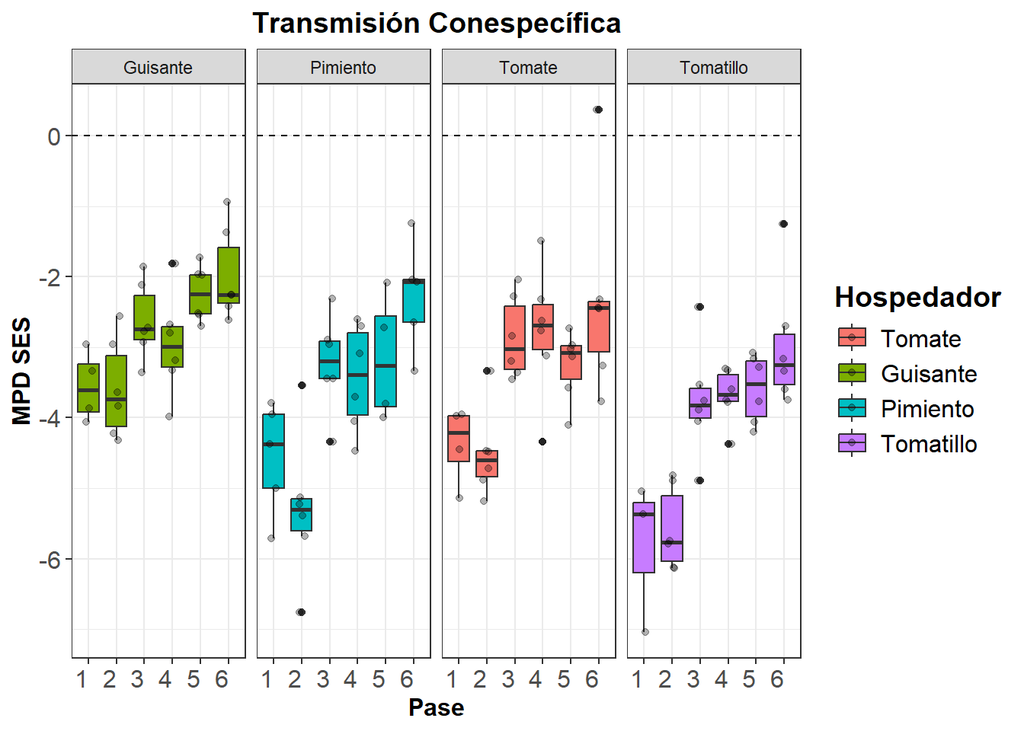

```r
MPD_SES_Conespecifica <- meta_new %>%
   filter(Tipo_linea == 'Conespecífica') %>%
  ggplot(aes(x = factor(Pase), y = mpd.obs.z_rare, fill = Hospedador)) +
  geom_hline(yintercept = 0, lty = 'dashed') +
  geom_boxplot() +
  ylab('MPD SES') +
  geom_point(position = position_jitterdodge(), alpha = 0.3) +
  facet_wrap(~Tipo_planta, ncol = 4) +
  ggtitle('Transmisión Conespecífica') +
  theme_bw() +
  labs(x = "Pase",
       fill = "Hospedador") +
    theme(
      axis.text.x = element_text(size = 12, hjust = 1),
      axis.text.y = element_text(size = 12),
      axis.title.x = element_text(size = 12, face = "bold"),
      axis.title.y = element_text(size = 12, face = "bold"),
      legend.text = element_text(size = 12),
      legend.title = element_text(size = 14, face="bold"),
      plot.title   = element_text(size = 14, face = "bold", hjust = 0.5)
    )

 MPD_SES_Conespecifica
```

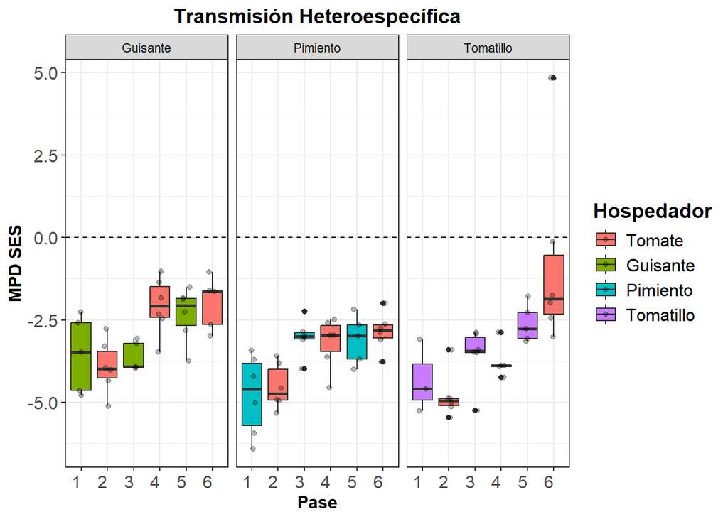

```r
MPD_SES_heteroespecifica <- meta_new %>%
  filter(Tipo_linea=='Heteroespecífica')%>%
  ggplot(aes(x=factor(Pase),y=mpd.obs.z_rare, fill=Hospedador)) +
  geom_hline(yintercept = 0, lty='dashed')+
  geom_boxplot() +
  ylab('MPD SES')+
  geom_point(position=position_jitterdodge(),alpha=0.3) +
  facet_wrap(~Tipo_planta, ncol = 4) +
  ggtitle('Transmisión Heteroespecífica')+
  theme_bw()+
  labs(x = "Pase",
       fill = "Hospedador")+
  theme(
      axis.text.x = element_text(size = 12, hjust = 1),
      axis.text.y = element_text(size = 12),
      axis.title.x = element_text(size = 12, face = "bold"),
      axis.title.y = element_text(size = 12, face = "bold"),
      legend.text = element_text(size = 12),
      legend.title = element_text(size = 14, face="bold"),
      plot.title   = element_text(size = 14, face = "bold", hjust = 0.5)
    )

MPD_SES_heteroespecifica
```

```r
panel <-    (MPD_SES_Conespecifica  + MPD_SES_heteroespecifica) +
            plot_layout(guides = "collect") +
            plot_annotation(tag_levels = "A", tag_suffix = ")") &
            theme(legend.position = "right")

ggsave("graficos/MPD.png", panel, width = 16, height = 6, dpi = 300)
```

# **Efectos de la especie de Hospedador**

## Efecto de la identidad de especie de Hospedador

Aquí se evalúa el efecto de la identidad del hospedador sobre la composición de las comunidades microbianas utilizando distancias Bray-Curtis y empleando una PERMANOVA.

1. Para las líneas conespecíficas se excluyen las muestras asociadas a tomate y se evalúa si Hospedador explica diferencias en la composición de las comunidades.
2. Para las líneas heteroespecíficas se utiliza la variable “Línea de hospedador” que contiene la especie de planta original:
- En los pases en los que no están en tomate se evalúa si la especie de planta explica diferencias en la composición.
- En los pases en los que están en tomate se evalúa si es posible detectar los efectos de la planta de origen sobre la composición de las comunidades.

```r
ps_Pase1_noT <- subset_samples(
  ps_nocontrol_filtrado_rare,
  Pase == 1 &  Hospedador != "Tomate"
)

#conespecifica
ps_Pase2C_noT <- subset_samples(
  ps_nocontrol_filtrado_rare,
  Pase == 2 & Tipo_linea == "Conespecífica" & Hospedador != "Tomate"
)
ps_Pase3C_noT <- subset_samples(
  ps_nocontrol_filtrado_rare,
  Pase == 3 & Tipo_linea == "Conespecífica" & Hospedador != "Tomate"
)
ps_Pase4C_noT <- subset_samples(
  ps_nocontrol_filtrado_rare,
  Pase == 4 & Tipo_linea == "Conespecífica" & Hospedador != "Tomate"
)
ps_Pase5C_noT <- subset_samples(
  ps_nocontrol_filtrado_rare,
  Pase == 5 & Tipo_linea == "Conespecífica" & Hospedador != "Tomate"
)
ps_Pase6C_noT <- subset_samples(
  ps_nocontrol_filtrado_rare,
  Pase == 6 & Tipo_linea == "Conespecífica" & Hospedador != "Tomate"
)


datos_est_Pase_1 <- as.data.frame(sample_data(ps_Pase1_noT), stringsAsFactors = FALSE)
datos_est_Pase_2 <- as.data.frame(sample_data(ps_Pase2C_noT), stringsAsFactors = FALSE)
datos_est_Pase_3 <- as.data.frame(sample_data(ps_Pase3C_noT), stringsAsFactors = FALSE)
datos_est_Pase_4 <- as.data.frame(sample_data(ps_Pase4C_noT), stringsAsFactors = FALSE)
datos_est_Pase_5 <- as.data.frame(sample_data(ps_Pase5C_noT), stringsAsFactors = FALSE)
datos_est_Pase_6 <- as.data.frame(sample_data(ps_Pase6C_noT), stringsAsFactors = FALSE)


ps_Pase1_noT_dist_bray <- as(otu_table(ps_Pase1_noT), "matrix")
if (taxa_are_rows(ps_Pase1_noT)) ps_Pase1_noT_dist_bray <- t(ps_Pase1_noT_dist_bray)

ps_Pase2C_noT_dist_bray <- as(otu_table(ps_Pase2C_noT), "matrix")
if (taxa_are_rows(ps_Pase2C_noT)) ps_Pase2C_noT_dist_bray <- t(ps_Pase2C_noT_dist_bray)

ps_Pase3C_noT_dist_bray <- as(otu_table(ps_Pase3C_noT), "matrix")
if (taxa_are_rows(ps_Pase3C_noT)) ps_Pase3C_noT_dist_bray <- t(ps_Pase3C_noT_dist_bray)

ps_Pase4C_noT_dist_bray <- as(otu_table(ps_Pase4C_noT), "matrix")
if (taxa_are_rows(ps_Pase4C_noT)) ps_Pase4C_noT_dist_bray <- t(ps_Pase4C_noT_dist_bray)

ps_Pase5C_noT_dist_bray <- as(otu_table(ps_Pase5C_noT), "matrix")
if (taxa_are_rows(ps_Pase5C_noT)) ps_Pase5C_noT_dist_bray <- t(ps_Pase5C_noT_dist_bray)

ps_Pase6C_noT_dist_bray <- as(otu_table(ps_Pase6C_noT), "matrix")
if (taxa_are_rows(ps_Pase6C_noT)) ps_Pase6C_noT_dist_bray <- t(ps_Pase6C_noT_dist_bray)


ps_Pase1_noT_bray <- vegdist(ps_Pase1_noT_dist_bray, method = "bray")
ps_Pase2C_noT_bray <- vegdist(ps_Pase2C_noT_dist_bray, method = "bray")
ps_Pase3C_noT_bray <- vegdist(ps_Pase3C_noT_dist_bray, method = "bray")
ps_Pase4C_noT_bray <- vegdist(ps_Pase4C_noT_dist_bray, method = "bray")
ps_Pase5C_noT_bray <- vegdist(ps_Pase5C_noT_dist_bray, method = "bray")
ps_Pase6C_noT_bray <- vegdist(ps_Pase6C_noT_dist_bray, method = "bray")

set.seed(134)

ps_Pase1_noT_bray_adonis <- adonis2(ps_Pase1_noT_bray ~ datos_est_Pase_1$Hospedador, permutations = 999, by = "terms")
ps_Pase2C_noT_bray_adonis <- adonis2(ps_Pase2C_noT_bray ~ datos_est_Pase_2$Hospedador, permutations = 999, by = "terms")
ps_Pase3C_noT_bray_adonis <- adonis2(ps_Pase3C_noT_bray ~ datos_est_Pase_3$Hospedador, permutations = 999, by = "terms")
ps_Pase4C_noT_bray_adonis <- adonis2(ps_Pase4C_noT_bray ~ datos_est_Pase_4$Hospedador, permutations = 999, by = "terms")
ps_Pase5C_noT_bray_adonis <- adonis2(ps_Pase5C_noT_bray ~ datos_est_Pase_5$Hospedador, permutations = 999, by = "terms")
ps_Pase6C_noT_bray_adonis <- adonis2(ps_Pase6C_noT_bray ~ datos_est_Pase_6$Hospedador, permutations = 999, by = "terms")
print(ps_Pase1_noT_bray_adonis)
```

```
## Permutation test for adonis under reduced model
## Terms added sequentially (first to last)
## Permutation: free
## Number of permutations: 999
##
## adonis2(formula = ps_Pase1_noT_bray ~ datos_est_Pase_1$Hospedador, permutations = 999, by = "terms")
##                             Df SumOfSqs    R2      F Pr(>F)
## datos_est_Pase_1$Hospedador  2   1.8457 0.229 3.4158  0.001 ***
## Residual                    23   6.2139 0.771
## Total                       25   8.0596 1.000
## ---
## Signif. codes:  0 '***' 0.001 '**' 0.01 '*' 0.05 '.' 0.1 ' ' 1
```

```r
print(ps_Pase2C_noT_bray_adonis)
```

```
## Permutation test for adonis under reduced model
## Terms added sequentially (first to last)
## Permutation: free
## Number of permutations: 999
##
## adonis2(formula = ps_Pase2C_noT_bray ~ datos_est_Pase_2$Hospedador, permutations = 999, by = "terms")
##                             Df SumOfSqs      R2      F Pr(>F)
## datos_est_Pase_2$Hospedador  2   1.5027 0.29161 3.0874  0.001 ***
## Residual                    15   3.6502 0.70839
## Total                       17   5.1529 1.00000
## ---
## Signif. codes:  0 '***' 0.001 '**' 0.01 '*' 0.05 '.' 0.1 ' ' 1
```

```r
print(ps_Pase3C_noT_bray_adonis)
```

```
## Permutation test for adonis under reduced model
## Terms added sequentially (first to last)
## Permutation: free
## Number of permutations: 999
##
## adonis2(formula = ps_Pase3C_noT_bray ~ datos_est_Pase_3$Hospedador, permutations = 999, by = "terms")
##                             Df SumOfSqs      R2      F Pr(>F)
## datos_est_Pase_3$Hospedador  2   2.3610 0.47945 6.9078  0.001 ***
## Residual                    15   2.5634 0.52055
## Total                       17   4.9244 1.00000
## ---
## Signif. codes:  0 '***' 0.001 '**' 0.01 '*' 0.05 '.' 0.1 ' ' 1
```

```r
print(ps_Pase4C_noT_bray_adonis)
```

```
## Permutation test for adonis under reduced model
## Terms added sequentially (first to last)
## Permutation: free
## Number of permutations: 999
##
## adonis2(formula = ps_Pase4C_noT_bray ~ datos_est_Pase_4$Hospedador, permutations = 999, by = "terms")
##                             Df SumOfSqs      R2      F Pr(>F)
## datos_est_Pase_4$Hospedador  2   1.5043 0.40064 5.0133  0.001 ***
## Residual                    15   2.2505 0.59936
## Total                       17   3.7549 1.00000
## ---
## Signif. codes:  0 '***' 0.001 '**' 0.01 '*' 0.05 '.' 0.1 ' ' 1
```

```r
print(ps_Pase5C_noT_bray_adonis)
```

```
## Permutation test for adonis under reduced model
## Terms added sequentially (first to last)
## Permutation: free
## Number of permutations: 999
##
## adonis2(formula = ps_Pase5C_noT_bray ~ datos_est_Pase_5$Hospedador, permutations = 999, by = "terms")
##                             Df SumOfSqs      R2      F Pr(>F)
## datos_est_Pase_5$Hospedador  2   1.5085 0.43636 5.0321  0.002 **
## Residual                    13   1.9486 0.56364
## Total                       15   3.4571 1.00000
## ---
## Signif. codes:  0 '***' 0.001 '**' 0.01 '*' 0.05 '.' 0.1 ' ' 1
```

```r
print(ps_Pase6C_noT_bray_adonis)
```

```
## Permutation test for adonis under reduced model
## Terms added sequentially (first to last)
## Permutation: free
## Number of permutations: 999
##
## adonis2(formula = ps_Pase6C_noT_bray ~ datos_est_Pase_6$Hospedador, permutations = 999, by = "terms")
##                             Df SumOfSqs      R2      F Pr(>F)
## datos_est_Pase_6$Hospedador  2   1.0182 0.39542 4.5784  0.001 ***
## Residual                    14   1.5567 0.60458
## Total                       16   2.5749 1.00000
## ---
## Signif. codes:  0 '***' 0.001 '**' 0.01 '*' 0.05 '.' 0.1 ' ' 1
```

```r
# lista de objetos adonis2 en el orden de los pases 1..6
ad_list <- list(ps_Pase1_noT_bray_adonis,
                ps_Pase2C_noT_bray_adonis,
                ps_Pase3C_noT_bray_adonis,
                ps_Pase4C_noT_bray_adonis,
                ps_Pase5C_noT_bray_adonis,
                ps_Pase6C_noT_bray_adonis)

# extraer R2 y p
R_vals <- sapply(ad_list, function(m) m[1, "R2"])
P_vals <- sapply(ad_list, function(m) m[1, "Pr(>F)"])

# comprobar tamaño de muestra por pase
ns <- c(nrow(datos_est_Pase_1), nrow(datos_est_Pase_2), nrow(datos_est_Pase_3),
        nrow(datos_est_Pase_4), nrow(datos_est_Pase_5), nrow(datos_est_Pase_6))



results_vert <- data.frame(Pase = 1:6,
                           Tipo_linea = "Conespecífica",
                           Variable = "Hospedador",
                           N = ns,
                           R = R_vals,
                           P = P_vals,
                           stringsAsFactors = FALSE)

# ajuste de p-values (Hochberg)
results_vert$P_adj <- p.adjust(results_vert$P, method = "hochberg")
results_vert$Significance <- ifelse(!is.na(results_vert$P_adj) & results_vert$P_adj < 0.05, "Sig", "NotSig")

print(results_vert)
```

```
##   Pase    Tipo_linea   Variable  N         R     P P_adj Significance
## 1    1 Conespecífica Hospedador 26 0.2290039 0.001 0.002          Sig
## 2    2 Conespecífica Hospedador 18 0.2916135 0.001 0.002          Sig
## 3    3 Conespecífica Hospedador 18 0.4794485 0.001 0.002          Sig
## 4    4 Conespecífica Hospedador 18 0.4006390 0.001 0.002          Sig
## 5    5 Conespecífica Hospedador 16 0.4363571 0.002 0.002          Sig
## 6    6 Conespecífica Hospedador 17 0.3954240 0.001 0.002          Sig
```

```r
# Heteroespecífica
ps_Pase2H <- subset_samples(ps_nocontrol_filtrado_rare,
                            Pase == 2 & Tipo_linea == "Heteroespecífica")
ps_Pase3H <- subset_samples(ps_nocontrol_filtrado_rare,
                            Pase == 3 & Tipo_linea == "Heteroespecífica")
ps_Pase4H <- subset_samples(ps_nocontrol_filtrado_rare,
                            Pase == 4 & Tipo_linea == "Heteroespecífica")
ps_Pase5H <- subset_samples(ps_nocontrol_filtrado_rare,
                            Pase == 5 & Tipo_linea == "Heteroespecífica")
ps_Pase6H <- subset_samples(ps_nocontrol_filtrado_rare,
                            Pase == 6 & Tipo_linea == "Heteroespecífica")

datos_est_Pase_2H <- as.data.frame(sample_data(ps_Pase2H), stringsAsFactors = FALSE)
datos_est_Pase_3H <- as.data.frame(sample_data(ps_Pase3H), stringsAsFactors = FALSE)
datos_est_Pase_4H <- as.data.frame(sample_data(ps_Pase4H), stringsAsFactors = FALSE)
datos_est_Pase_5H <- as.data.frame(sample_data(ps_Pase5H), stringsAsFactors = FALSE)
datos_est_Pase_6H <- as.data.frame(sample_data(ps_Pase6H), stringsAsFactors = FALSE)

# construir matrices OTU y trasponer si es necesario

ps_Pase2H_dist <- as(otu_table(ps_Pase2H), "matrix"); if(taxa_are_rows(ps_Pase2H)) ps_Pase2H_dist <- t(ps_Pase2H_dist)
ps_Pase3H_dist <- as(otu_table(ps_Pase3H), "matrix"); if(taxa_are_rows(ps_Pase3H)) ps_Pase3H_dist <- t(ps_Pase3H_dist)
ps_Pase4H_dist <- as(otu_table(ps_Pase4H), "matrix"); if(taxa_are_rows(ps_Pase4H)) ps_Pase4H_dist <- t(ps_Pase4H_dist)
ps_Pase5H_dist <- as(otu_table(ps_Pase5H), "matrix"); if(taxa_are_rows(ps_Pase5H)) ps_Pase5H_dist <- t(ps_Pase5H_dist)
ps_Pase6H_dist <- as(otu_table(ps_Pase6H), "matrix"); if(taxa_are_rows(ps_Pase6H)) ps_Pase6H_dist <- t(ps_Pase6H_dist)


# calcular distancias Bray (si hay al menos 2 muestras; si no, devolverá error)
ps_Pase2H_bray <- if(nrow(ps_Pase2H_dist) >= 2) vegdist(ps_Pase2H_dist, method = "bray") else NULL
ps_Pase3H_bray <- if(nrow(ps_Pase3H_dist) >= 2) vegdist(ps_Pase3H_dist, method = "bray") else NULL
ps_Pase4H_bray <- if(nrow(ps_Pase4H_dist) >= 2) vegdist(ps_Pase4H_dist, method = "bray") else NULL
ps_Pase5H_bray <- if(nrow(ps_Pase5H_dist) >= 2) vegdist(ps_Pase5H_dist, method = "bray") else NULL
ps_Pase6H_bray <- if(nrow(ps_Pase6H_dist) >= 2) vegdist(ps_Pase6H_dist, method = "bray") else NULL

# ejecutar adonis2 (Línea de Hospedador como variable)

ps_Pase2H_bray_adonis <- if(!is.null(ps_Pase2H_bray)) adonis2(ps_Pase2H_bray ~ datos_est_Pase_2H$Linea_de_Hospedador, permutations = 999, by = "terms") else NULL
ps_Pase3H_bray_adonis <- if(!is.null(ps_Pase3H_bray)) adonis2(ps_Pase3H_bray ~ datos_est_Pase_3H$Linea_de_Hospedador, permutations = 999, by = "terms") else NULL
ps_Pase4H_bray_adonis <- if(!is.null(ps_Pase4H_bray)) adonis2(ps_Pase4H_bray ~ datos_est_Pase_4H$Linea_de_Hospedador, permutations = 999, by = "terms") else NULL
ps_Pase5H_bray_adonis <- if(!is.null(ps_Pase5H_bray)) adonis2(ps_Pase5H_bray ~ datos_est_Pase_5H$Linea_de_Hospedador, permutations = 999, by = "terms") else NULL
ps_Pase6H_bray_adonis <- if(!is.null(ps_Pase6H_bray)) adonis2(ps_Pase6H_bray ~ datos_est_Pase_6H$Linea_de_Hospedador, permutations = 999, by = "terms") else NULL

# imprimir resultados (mostrará NULL si no había suficientes muestras en un pase)
print(ps_Pase2H_bray_adonis)
```

```
## Permutation test for adonis under reduced model
## Terms added sequentially (first to last)
## Permutation: free
## Number of permutations: 999
##
## adonis2(formula = ps_Pase2H_bray ~ datos_est_Pase_2H$Linea_de_Hospedador, permutations = 999, by = "terms")
##                                       Df SumOfSqs     R2      F Pr(>F)
## datos_est_Pase_2H$Linea_de_Hospedador  2   0.5028 0.1221 1.0431  0.409
## Residual                              15   3.6151 0.8779
## Total                                 17   4.1179 1.0000
```

```r
print(ps_Pase3H_bray_adonis)
```

```
## Permutation test for adonis under reduced model
## Terms added sequentially (first to last)
## Permutation: free
## Number of permutations: 999
##
## adonis2(formula = ps_Pase3H_bray ~ datos_est_Pase_3H$Linea_de_Hospedador, permutations = 999, by = "terms")
##                                       Df SumOfSqs      R2      F Pr(>F)
## datos_est_Pase_3H$Linea_de_Hospedador  2   1.6313 0.37376 4.1778  0.001 ***
## Residual                              14   2.7332 0.62624
## Total                                 16   4.3644 1.00000
## ---
## Signif. codes:  0 '***' 0.001 '**' 0.01 '*' 0.05 '.' 0.1 ' ' 1
```

```r
print(ps_Pase4H_bray_adonis)
```

```
## Permutation test for adonis under reduced model
## Terms added sequentially (first to last)
## Permutation: free
## Number of permutations: 999
##
## adonis2(formula = ps_Pase4H_bray ~ datos_est_Pase_4H$Linea_de_Hospedador, permutations = 999, by = "terms")
##                                       Df SumOfSqs      R2      F Pr(>F)
## datos_est_Pase_4H$Linea_de_Hospedador  2   0.7159 0.16226 1.3558  0.161
## Residual                              14   3.6959 0.83774
## Total                                 16   4.4118 1.00000
```

```r
print(ps_Pase5H_bray_adonis)
```

```
## Permutation test for adonis under reduced model
## Terms added sequentially (first to last)
## Permutation: free
## Number of permutations: 999
##
## adonis2(formula = ps_Pase5H_bray ~ datos_est_Pase_5H$Linea_de_Hospedador, permutations = 999, by = "terms")
##                                       Df SumOfSqs      R2      F Pr(>F)
## datos_est_Pase_5H$Linea_de_Hospedador  2   1.5212 0.39692 4.2779  0.001 ***
## Residual                              13   2.3113 0.60308
## Total                                 15   3.8325 1.00000
## ---
## Signif. codes:  0 '***' 0.001 '**' 0.01 '*' 0.05 '.' 0.1 ' ' 1
```

```r
print(ps_Pase6H_bray_adonis)
```

```
## Permutation test for adonis under reduced model
## Terms added sequentially (first to last)
## Permutation: free
## Number of permutations: 999
##
## adonis2(formula = ps_Pase6H_bray ~ datos_est_Pase_6H$Linea_de_Hospedador, permutations = 999, by = "terms")
##                                       Df SumOfSqs      R2      F Pr(>F)
## datos_est_Pase_6H$Linea_de_Hospedador  2   0.7753 0.21063 1.8678  0.043 *
## Residual                              14   2.9057 0.78937
## Total                                 16   3.6811 1.00000
## ---
## Signif. codes:  0 '***' 0.001 '**' 0.01 '*' 0.05 '.' 0.1 ' ' 1
```

```r
ad_list_H <- list(ps_Pase3H_bray_adonis,
                ps_Pase5H_bray_adonis)

# extraer R2 y p
R_vals_H <- sapply(ad_list_H, function(m) m[1, "R2"])
P_vals_H <- sapply(ad_list_H, function(m) m[1, "Pr(>F)"])

# comprobar tamaño de muestra por pase
ns_H <- c(nrow(datos_est_Pase_3H),nrow(datos_est_Pase_5H))

results_H <- data.frame(Pase = c(3,5),
                           Tipo_linea = "Heteroespecífica",
                           Variable = "Linea_de_Hospedador",
                           N = ns_H,
                           R = R_vals_H,
                           P = P_vals_H,
                           stringsAsFactors = FALSE)

# ajuste de p-values (Hochberg)
results_H$P_adj <- p.adjust(results_H$P, method = "hochberg")
results_H$Significance <- ifelse(!is.na(results_H$P_adj) & results_H$P_adj < 0.05, "Sig", "NotSig")

print(results_H)
```

```
##   Pase       Tipo_linea            Variable  N         R     P P_adj
## 1    3 Heteroespecífica Linea_de_Hospedador 17 0.3737610 0.001 0.001
## 2    5 Heteroespecífica Linea_de_Hospedador 16 0.3969152 0.001 0.001
##   Significance
## 1          Sig
## 2          Sig
```

```r
#Paso Final

# 1) Unir tablas
df_all <- bind_rows(results_vert, results_H)
a <- df_all [1,]
a [1,2] <- "Heteroespecífica"
df_all <- bind_rows(a, df_all)

# 2) Asegurar nombres/tipos
df_all$Pase <- factor(as.character(df_all$Pase), levels = as.character(1:6))
df_all$Treatment <- factor(df_all$Tipo_linea, levels = c("Conespecífica", "Heteroespecífica"))

# 3) (Opcional) recalcular P_adj si no existe o quieres recomputar
if(!("P_adj" %in% colnames(df_all))){
  df_all <- df_all %>%
    group_by(Treatment, Variable) %>%
    mutate(P_for_adj = ifelse(is.na(P), 1, P),
           P_adj = {padj <- p.adjust(P_for_adj, method = "hochberg"); padj[is.na(P)] <- NA; padj}) %>%
    ungroup() %>%
    select(-P_for_adj)
}

# Comprobar la consistencia de P_adj
df_all$Significance <- ifelse(!is.na(df_all$P_adj) & df_all$P_adj < 0.05, "Sig", "NotSig")



# 4) Preparar dataframe para plot (variable de interés = "Hospedador")
df_plot <- df_all


PermRPlot_combined <- df_plot %>%
  ggplot(aes(x = Pase, y = as.numeric(R), group = Tipo_linea)) +
  geom_line(aes(color = Tipo_linea, linetype = Tipo_linea), size = 2.5) +
  geom_point(aes(shape = Tipo_linea, fill = Tipo_linea), color = "black", size = 5.2, show.legend = TRUE) +
  scale_linetype_manual(values = c("solid", "dotdash"), labels = c("Conespecífica", "Heteroespecífica")) +
  scale_shape_manual(values = c(21, 22), labels = c("Conespecífica", "Heteroespecífica")) +
  scale_fill_manual(values = c("darkred", "steelblue")) +
  scale_color_manual(values = c("darkred", "steelblue")) +
  ylab(expression("PERMANOVA " * italic(R)^2)) +
  theme_minimal() +
  ggtitle('Efecto de la identidad de la especie de Hospedador') +
  labs(color = "Modo de transmisión",
     fill = "Modo de transmisión",
     shape = "Modo de transmisión",
     linetype = "Modo de transmisión") +
  theme(title = element_text(size = 22),
        axis.title = element_text(size = 17),
        axis.text = element_text(size = 17),
        legend.text = element_text(size = 17),
          legend.position = c(0.83, 0.2),
          legend.background = element_rect(fill = "white", color = "black"),
        legend.title = element_text(size = 20),
        panel.grid.minor = element_blank(), panel.grid.major = element_blank(),
        panel.background = element_rect(colour = "black", size = 1)) +
  theme(legend.key.width = unit(1.4, "cm")) +
  scale_x_discrete(expand = c(0.05, 0.05))
# PermRPlot_combined


ggsave("graficos/identidad_hospedador.png",
       plot = PermRPlot_combined, width = 10, height = 6, dpi = 300)


#Efecto de filtrado de Hospeador cuando es Tomate

ad_list_H_246 <- list(ps_Pase2H_bray_adonis,
                ps_Pase4H_bray_adonis,
                ps_Pase6H_bray_adonis)

# extraer R2 y p
R_vals_H_246 <- sapply(ad_list_H_246, function(m) m[1, "R2"])
P_vals_H246 <- sapply(ad_list_H_246, function(m) m[1, "Pr(>F)"])

# comprobar tamaño de muestra por pase
ns_H <- c(nrow(datos_est_Pase_2H), nrow(datos_est_Pase_4H),nrow(datos_est_Pase_6H))

results_H_246 <- data.frame(Pase = c(2,4,6),
                           Tipo_linea = "Heteroespecífica",
                           Variable = "Linea_de_Hospedador",
                           N = ns_H,
                           R = R_vals_H_246,
                           P = P_vals_H246,
                           stringsAsFactors = FALSE)

# ajuste de p-values (Hochberg)
results_H_246$P_adj <- p.adjust(results_H_246$P, method = "hochberg")
results_H_246$Significance <- ifelse(!is.na(results_H_246$P_adj) & results_H_246$P_adj < 0.05, "Sig", "NotSig")

print(results_H_246)
```

```
##   Pase       Tipo_linea            Variable  N         R     P P_adj
## 1    2 Heteroespecífica Linea_de_Hospedador 18 0.1220955 0.409 0.409
## 2    4 Heteroespecífica Linea_de_Hospedador 17 0.1622615 0.161 0.322
## 3    6 Heteroespecífica Linea_de_Hospedador 17 0.2106299 0.043 0.129
##   Significance
## 1       NotSig
## 2       NotSig
## 3       NotSig
```

## Efecto de hospedador previo

En este apartado se evalúa el efecto del hospedador previo sobre la composición microbiana cuando las líneas heteroespecíficas están en tomate. Se comparan para cada pase (2, 4 y 6) cada tipo de línea heteroespecífica con las conespecíficas de tomate. Se realiza una PERMANOVA basada en distancias Bray-Curtis utilizando como variable “Línea de Hospedador” (que contiene información de la especie de planta original). Por último, se realiza una PCA sobre la matriz de abundancias.

```r
set.seed(134)


Grupo_cones <- "Tomate_Conespecífica"

# Hetererospecificas
GH <- "Guisante_Heteroespecífica"
PH <- "Pimiento_Heteroespecífica"
TH <- "Tomatillo_Heteroespecífica"

# ---- Pase 2 pares ----
ps_P2_GH <- subset_samples(ps_nocontrol_filtrado_rare, Pase == "2" & Hospedador == "Tomate" & Linea_de_Hospedador %in% c(Grupo_cones, GH))
ps_P2_PH <- subset_samples(ps_nocontrol_filtrado_rare, Pase == "2" & Hospedador == "Tomate" & Linea_de_Hospedador %in% c(Grupo_cones, PH))
ps_P2_TH <- subset_samples(ps_nocontrol_filtrado_rare, Pase == "2" & Hospedador == "Tomate" & Linea_de_Hospedador %in% c(Grupo_cones, TH))

# ---- Pase 4 pares ----
ps_P4_GH <- subset_samples(ps_nocontrol_filtrado_rare, Pase == "4" & Hospedador == "Tomate" & Linea_de_Hospedador %in% c(Grupo_cones, GH))
ps_P4_PH <- subset_samples(ps_nocontrol_filtrado_rare, Pase == "4" & Hospedador == "Tomate" & Linea_de_Hospedador %in% c(Grupo_cones, PH))
ps_P4_TH <- subset_samples(ps_nocontrol_filtrado_rare, Pase == "4" & Hospedador == "Tomate" & Linea_de_Hospedador %in% c(Grupo_cones, TH))

# ---- Pase 6 pares ----
ps_P6_GH <- subset_samples(ps_nocontrol_filtrado_rare, Pase == "6" & Hospedador == "Tomate" & Linea_de_Hospedador %in% c(Grupo_cones, GH))
ps_P6_PH <- subset_samples(ps_nocontrol_filtrado_rare, Pase == "6" & Hospedador == "Tomate" & Linea_de_Hospedador %in% c(Grupo_cones, PH))
ps_P6_TH <- subset_samples(ps_nocontrol_filtrado_rare, Pase == "6" & Hospedador == "Tomate" & Linea_de_Hospedador %in% c(Grupo_cones, TH))

# ---- función pequeña para calcular adonis2 para un phyloseq ya filtrado ----
adonis_for_ps <- function(ps_obj) {
  n <- length(sample_names(ps_obj))
  if (n < 4) return(data.frame(R2 = NA_real_, p = NA_real_, N = n))
  otu_mat <- as(otu_table(ps_obj), "matrix")
  if (taxa_are_rows(ps_obj)) otu_mat <- t(otu_mat)
  d <- vegdist(otu_mat, method = "bray")
  md <- as.data.frame(sample_data(ps_obj), stringsAsFactors = FALSE)
  ad <- adonis2(d ~ md$Linea_de_Hospedador, permutations = 4999)
  data.frame(R2 = ad[1,"R2"], p = ad[1,"Pr(>F)"], N = n)
}

# ---- calcular todos los adonis explícitamente ----

set.seed(134)

r_P2_GH <- adonis_for_ps(ps_P2_GH)
r_P2_PH <- adonis_for_ps(ps_P2_PH)
r_P2_TH <- adonis_for_ps(ps_P2_TH)

r_P4_GH <- adonis_for_ps(ps_P4_GH)
r_P4_PH <- adonis_for_ps(ps_P4_PH)
r_P4_TH <- adonis_for_ps(ps_P4_TH)

r_P6_GH <- adonis_for_ps(ps_P6_GH)
r_P6_PH <- adonis_for_ps(ps_P6_PH)
r_P6_TH <- adonis_for_ps(ps_P6_TH)

# ---- juntar resultados en un data.frame ----
res_pairs2 <- data.frame(
  Pase = rep(c(2,4,6), each = 3),
  Grupo_Heter = c(GH, PH, TH, GH, PH, TH, GH, PH, TH),
  N = c(r_P2_GH$N, r_P2_PH$N, r_P2_TH$N,
        r_P4_GH$N, r_P4_PH$N, r_P4_TH$N,
        r_P6_GH$N, r_P6_PH$N, r_P6_TH$N),
  R2 = c(r_P2_GH$R2, r_P2_PH$R2, r_P2_TH$R2,
         r_P4_GH$R2, r_P4_PH$R2, r_P4_TH$R2,
         r_P6_GH$R2, r_P6_PH$R2, r_P6_TH$R2),
  p = c(r_P2_GH$p, r_P2_PH$p, r_P2_TH$p,
        r_P4_GH$p, r_P4_PH$p, r_P4_TH$p,
        r_P6_GH$p, r_P6_PH$p, r_P6_TH$p),
  stringsAsFactors = FALSE
)

# ajustar p dentro de cada pase (Hochberg)
res_pairs2$padj <- NA_real_
for (p in unique(res_pairs2$Pase)) {
  idx <- which(res_pairs2$Pase == p)
  res_pairs2$padj[idx] <- p.adjust(res_pairs2$p[idx], method = "hochberg")
}

print(res_pairs2)
```

```
##   Pase                Grupo_Heter  N         R2      p   padj
## 1    2  Guisante_Heteroespecífica 12 0.08714957 0.5084 0.8800
## 2    2  Pimiento_Heteroespecífica 12 0.09950764 0.3506 0.8800
## 3    2 Tomatillo_Heteroespecífica 12 0.05649445 0.8800 0.8800
## 4    4  Guisante_Heteroespecífica 12 0.08572424 0.5370 0.5984
## 5    4  Pimiento_Heteroespecífica 12 0.12135913 0.1734 0.5202
## 6    4 Tomatillo_Heteroespecífica 11 0.08501010 0.5984 0.5984
## 7    6  Guisante_Heteroespecífica 11 0.08943118 0.4938 0.4938
## 8    6  Pimiento_Heteroespecífica 12 0.12440470 0.1788 0.3576
## 9    6 Tomatillo_Heteroespecífica 12 0.25482498 0.0118 0.0354
```

```r
#Gráfico PCA

# 1) Extraer OTU matrix
otu_mat <- as(otu_table(ps_nocontrol_filtrado_rare), "matrix")
if (taxa_are_rows(ps_nocontrol_filtrado_rare)) otu_mat <- t(otu_mat)

# 2) Crear ps_prop
ps_prop <- transform_sample_counts(ps_nocontrol_filtrado_rare, function(x) x / sum(x))
Z <- as(otu_table(ps_prop), "matrix")
if (taxa_are_rows(ps_prop)) Z <- t(Z)


# 4) PCAs
# PCA sobre la tabla original (otu_mat)
pca_raw <- prcomp(otu_mat, center = TRUE, scale. = FALSE)
summary(pca_raw)
```

[output not shown]

[output cut: 94 more lines]

[output not shown]

[figure not shown]

```r
# añadir directamente
datos_est$PC1_raw <- pca_raw$x[rownames(datos_est), 1]
datos_est$PC2_raw <- pca_raw$x[rownames(datos_est), 2]




PCA_Plot_hospprevio_raw <- datos_est %>%
  filter(Pase == '2' | Pase == '4' | Pase == '6') %>%
  filter(Linea_de_Hospedador == 'Tomatillo_Heteroespecífica' | Linea_de_Hospedador == 'Pimiento_Heteroespecífica' |
           Linea_de_Hospedador == 'Guisante_Heteroespecífica') %>%
  ggplot(aes(x=PC1_raw, y=PC2_raw))+
  geom_point(aes(PC1_raw, PC2_raw, colour = factor(Linea_de_Hospedador),
                 shape = factor(Pase)), size = 3)+
  scale_colour_manual(values= c("#7CAE00","#00BFC4", '#C77CFF'),
                      labels = c('Tomatillo heteroespecífico',
                                 'Pimiento heteroespecífico','Guisante heteroespecífico')) +
  scale_shape_manual(values = c(15,17,19)) +
  coord_fixed()+
  ggtitle('Efecto de Hospedador previo') +
  theme_classic()+
  theme(panel.background = element_rect(fill = NA, colour = "black", size = 1, linetype = "solid"))+
  labs(colour = "Linea de Hospedador", shape = "Pase", x = "PC1 (35,65%)",
       y = "PC2 (6,56%)")+
  theme(title = element_text(size = 20),
        axis.title = element_text(size = 17),
        axis.text = element_text(size = 17),
        legend.position = "right",
        legend.text = element_text(size = 14),
        legend.title = element_text(size = 15),
        )


PCA_Plot_hospprevio_raw
```

```r
ggsave("graficos/PCA_hosp_previo.png",
       plot = PCA_Plot_hospprevio_raw, width = 10, height = 6, dpi = 300)
```

# **Enriquecimiento de taxones**

## Análisis Bayesiano

En el script llamado análisis ASVs se analiza si se ha producido un enriquecimiento diferencial de algunos taxones según el modo de transmisión